# Practicum2.CS5200Su21

Authors: Sunjit Dhillon [dhillon.su@northeastern.edu] MManzur Morshed [morshed.mm@northeastern.edu]

#Part1 Q1: # ERD Link https://lucid.app/lucidchart/f33caea1-b422-42a8-9df6-1c44fdd7e24c/edit?invitationId=inv_1a981c70-a61d-471a-827a-0388f1946d43

#ERD image

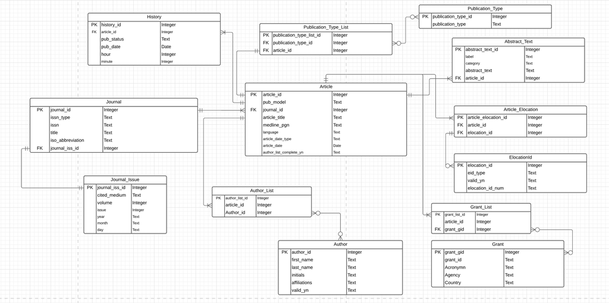

#Part1 Q2: # Creating SQLite DB # Creating all the tables from ERD above

```r
library(RSQLite)
library(dplyr)
library(sqldf)
```

```r
library(XML)
library(ggplot2)

#fpath = "/Users/sunjitdhillon/Desktop/"
fpath = "/Users/mmorshed/sqlite/"
dbfile = "pubmedDB.db"
dbcon <- dbConnect(RSQLite::SQLite(), paste0(fpath,dbfile))
```

```sql
PRAGMA foreign_keys = ON
```

```sql
DROP TABLE IF EXISTS Journal_Issue
```

```sql
CREATE TABLE Journal_Issue(
journal_iss_id INTEGER NOT NULL,
cited_medium TEXT,
volume INTEGER,
issue INTEGER,
year TEXT,
month TEXT,
day TEXT,
PRIMARY KEY (journal_iss_id)
)
```

```sql
DROP TABLE IF EXISTS Journal;
```

```sql
CREATE TABLE Journal(
journal_id INTEGER NOT NULL,
issn_type TEXT,
issn TEXT,
title TEXT,
iso_abbreviation TEXT,
journal_iss_id INTEGER,
PRIMARY KEY (journal_id),
FOREIGN KEY (journal_iss_id) REFERENCES Journal_Issue(journal_iss_id) ON DELETE CASCADE
)
```

```sql
DROP TABLE IF EXISTS Author
```

```sql
CREATE TABLE Author (
author_id INTEGER NOT NULL,
last_name TEXT,
fore_name TEXT,
initials TEXT,
affiliations TEXT,
valid_yn TEXT,
PRIMARY KEY (author_id)
)
```

```sql
DROP TABLE IF EXISTS Elocation_Id
```

```sql
CREATE TABLE Elocation_Id (
elocation_id INTEGER NOT NULL,
eid_type TEXT,
valid_yn TEXT,
elocation_id_num TEXT,
PRIMARY KEY (elocation_id)
)
```

```sql
DROP TABLE IF EXISTS Grant
```

```sql
CREATE TABLE Grant (
grant_gid INTEGER NOT NULL,
grant_id INTEGER,
acronym TEXT,
agency TEXT,
country TEXT,
PRIMARY KEY (grant_gid)
)
```

```sql
DROP TABLE IF EXISTS Article
```

```sql
CREATE TABLE Article(
article_id INTEGER NOT NULL,
pub_model TEXT,
journal_id INTEGER,
article_title TEXT,
medline_pgn TEXT,
language TEXT,
article_date_type TEXT,
article_date DATE,
author_list_complete_yn TEXT,
PRIMARY KEY (article_id),
FOREIGN KEY (journal_id) references Journal(journal_id) ON DELETE CASCADE
)
```

```sql
DROP TABLE IF EXISTS Article_Elocation
```

```sql
CREATE TABLE Article_Elocation (
article_elocation_id INTEGER NOT NULL,
article_id INTEGER NOT NULL,
elocation_id INTEGER NOT NULL,
PRIMARY KEY (article_elocation_id),
FOREIGN KEY (article_id) REFERENCES Article(article_id) ON DELETE CASCADE,
FOREIGN KEY (elocation_id) REFERENCES Elocation_Id(elocation_id) ON DELETE CASCADE

)
```

```sql
DROP TABLE IF EXISTS Author_List
```

```sql
CREATE TABLE Author_List (
author_list_id INTEGER NOT NULL,
article_id INTEGER NOT NULL,
author_id INTEGER NOT NULL,
PRIMARY KEY (author_list_id),
FOREIGN KEY (article_id) REFERENCES Article(article_id) ON DELETE CASCADE,
FOREIGN KEY (author_id) REFERENCES Author(author_id) ON DELETE CASCADE
)
```

```sql
DROP TABLE IF EXISTS Grant_List
```

```sql
CREATE TABLE Grant_List (
grant_list_id INTEGER NOT NULL,
article_id INTEGER NOT NULL,
grant_gid INTEGER NOT NULL,
PRIMARY KEY (grant_list_id),
FOREIGN KEY (article_id) REFERENCES Article(article_id) ON DELETE CASCADE,
FOREIGN KEY (grant_gid) REFERENCES Grant(grant_gid) ON DELETE CASCADE
)
```

```sql
DROP TABLE IF EXISTS Abstract_Text
```

```sql
CREATE TABLE Abstract_Text (
abstract_text_id INTEGER NOT NULL,
label TEXT,
category TEXT,
abstract_text TEXT,
article_id INTEGER NOT NULL,
PRIMARY KEY (abstract_text_id),
FOREIGN KEY (article_id) REFERENCES Article(article_id) ON DELETE CASCADE
)
```

```sql
DROP TABLE IF EXISTS History
```

```sql
CREATE TABLE History (
history_id INTEGER NOT NULL,
article_id INTEGER NOT NULL,
pub_status TEXT,
pub_date DATE,
hour INTEGER,
minute INTEGER,
PRIMARY KEY (history_id),
FOREIGN KEY (article_id) REFERENCES Article(article_id) ON DELETE CASCADE
)
```

```sql
DROP TABLE IF EXISTS Publication_Type
```

```sql
CREATE TABLE Publication_Type (
publication_type_id INTEGER NOT NULL,
publication_type TEXT,
PRIMARY KEY (publication_type_id)
)
```

```sql
DROP TABLE IF EXISTS Publication_Type_List
```

```sql
CREATE TABLE Publication_Type_List (
publication_type_list_id INTEGER NOT NULL,
publication_type_id INTEGER NOT NULL,
article_id INTEGER NOT NULL,
PRIMARY KEY (publication_type_list_id),
FOREIGN KEY (publication_type_id) REFERENCES Publication_Type(publication_type_id) ON DELETE CASCADE,
FOREIGN KEY (article_id) REFERENCES Article(article_id) ON DELETE CASCADE
)
```

#Part1 Q3 #Extracting and transforming the data from the XML and then loading into the appropriate tables in the database.

```r
#path <- "/Users/sunjitdhillon/Downloads/"
path <- "/Users/mmorshed/Downloads/"
fn <- "pubmed_sample.xml"
fpn = paste0(path, fn)
```

```r
# Reading the XML file and parse into DOM
xmlDOM <- xmlParse(file = fpn)

# get the root node of the DOM tree
r <- xmlRoot(xmlDOM)

# get number of children of root
numPO <- xmlSize(r)
numPO
```

```
## [1] 19
```

```r
# Creating Author.df for authors' data. Don't know how many unique authors are there, so not defining the size.
Author.df <- data.frame (author_id = integer(),
                          last_name = character(),
                          fore_name = character(),
                          initials = character(),
                          affiliations = character(),
                          valid_yn = character(),
                          stringsAsFactors = F)
```

```r
# Populating Author.df

xpathEx <- "/PubmedArticleSet/PubmedArticle/MedlineCitation/Article/AuthorList/Author"

authors <- xpathSApply(xmlDOM, xpathEx)

id <- 0
for (k in 1:length(authors)) {

  current_author <- authors[[k]]
  #Last Name
  cur_value <- current_author[["LastName"]]
  if (! is.null(cur_value)) {
    temp <- xmlValue(cur_value)
  } else {
    temp <- NA
  }
  last_name <- temp

  #Fore Name

  cur_value <- current_author[["ForeName"]]
  if (! is.null(cur_value)) {
    temp <- xmlValue(cur_value)
  } else {
    temp <- NA
  }
  fore_name <- temp

  cur_value <- current_author[["Initials"]]
  if (! is.null(cur_value)) {
    temp <- xmlValue(cur_value)
  } else {
    temp <- NA
  }
  initials <- temp

  cur_value <- current_author[["Affiliation"]]
  if (! is.null(cur_value)) {
    temp <- xmlValue(cur_value)
  } else {
    temp <- NA
  }
  affiliations <- temp

  #cur_value <- xmlAttrs(current_author)
  if (! is.null(current_author)) {
    attr_list <- xmlAttrs(current_author)
    temp <- xmlGetAttr(current_author, "ValidYN")
  } else {
    temp <- NA
  }
  valid_yn <- temp


  # travel through existing data frame to see if this name already exists
  duplicate <- 0
  for (i in 1:nrow(Author.df)) {

    if (nrow(Author.df) < 2) {
      break
    }

    if (last_name == Author.df$last_name[i] && fore_name == Author.df$fore_name[i] && initials == Author.df$initials[i]) {
      duplicate <- 1
    }
  }

  if(duplicate == 0) {
  j <- nrow(Author.df)+1

  id <- id + 1
  Author.df[j,1] <- id
  Author.df[j,2] <- last_name
  Author.df[j,3] <- fore_name
  Author.df[j,4] <- initials
  Author.df[j,5] <- affiliations
  Author.df[j,6] <- valid_yn
  }
}


head(Author.df)
```

|  | author_id | last_name | fore_name | initials | affiliations | valid_yn |
| --- | --- | --- | --- | --- | --- | --- |
| 1 | 1 | Kuo | Cassie | C | Department of Anesthesiology, Hospital for Special Surgery, 535 East 70th Street, New York, NY 10021 USA. | Y |
| 2 | 2 | Edwards | Alison | A | NA | Y |
| 3 | 3 | Mazumdar | Madhu | M | NA | Y |
| 4 | 4 | Memtsoudis | Stavros G | SG | NA | Y |
| 5 | 5 | Stundner | Ottokar | O | Department of Anesthesiology, Hospital for Special Surgery, Weill Medical College of Cornell University, New York, NY, USA. | Y |
| 6 | 6 | Kirksey | Meghan | M | NA | Y |

```r
# Creating Journalissue.df. Don't know how many unique journal issues are there, so not defining the size.
Journalissue.df <- data.frame (journal_iss_id = integer(),
                          cited_medium = character(),
                          volume = integer(),
                          issue = integer(),
                          year = integer(),
                          month = character(),
                          day = character(),
                          stringsAsFactors = F)
```

```r
# Populating Journalissue.df
xpathEx <- "/PubmedArticleSet/PubmedArticle/MedlineCitation/Article/Journal/JournalIssue"

journal_issue <- xpathSApply(xmlDOM, xpathEx)
#journal_issue

id <- 0
for (k in 1:length(journal_issue)) {
  current_jissue <- journal_issue[[k]]

  if (! is.null(current_jissue)) {
    attr_list <- xmlAttrs(current_jissue)
    temp <- xmlGetAttr(current_jissue, "CitedMedium")
  } else {
    temp <- NA
  }
  cited_medium <- temp

  #Volume
  cur_value <- current_jissue[["Volume"]]
  if (! is.null(cur_value)) {
    temp <- xmlValue(cur_value)
  } else {
    temp <- NA
  }
  volume <- temp

  #Issue
  cur_value <- current_jissue[["Issue"]]
  if (! is.null(cur_value)) {
    temp <- xmlValue(cur_value)
  } else {
    temp <- NA
  }
  issue <- temp

  #Year
  cur_value <- current_jissue[["PubDate"]]
  if (! is.null(cur_value)) {
  cur_year <- cur_value[["Year"]]
  if (! is.null(cur_year)) {
    temp <- xmlValue(cur_year)
  } else {
    temp <- NA
  }
  year <- temp

  #Month
  cur_month <- cur_value[["Month"]]
  if (! is.null(cur_month)) {
    temp <- xmlValue(cur_month)
  } else {
    temp <- NA
  }
  month <- temp

  #Day
  cur_day <- cur_value[["Day"]]
  if (! is.null(cur_day)) {
    temp <- xmlValue(cur_day)
  } else {
    temp <- NA
  }
  day <- temp
  } else {
    year <- NA
    month <- NA
    day <- NA
  }


  cur_medline_date <-  cur_value[["MedlineDate"]]
  if(! is.null(cur_medline_date)) {
    medline_date <- xmlValue(cur_medline_date)
    split_date <- strsplit(medline_date, " ")[[1]]
    year <- split_date[1]
    split_months <- strsplit(split_date[2:3], "-")[[1]]
    month <- split_months[1]
  }


  # travel through existing data frame to see if this name already exists
  duplicate <- 0
  for (i in 1:nrow(Journalissue.df)) {

    if (nrow(Journalissue.df) < 2) {
      break
    }
    # checking
    if (cited_medium == Journalissue.df$cited_medium[i] && volume == Journalissue.df$volume[i] && issue == Journalissue.df$issue[i]    && year == Journalissue.df$year && month == Journalissue.df$month && day == Journalissue.df$day) {
      duplicate <- 1
    }
  }

  if(duplicate == 0) {
  j <- nrow(Journalissue.df)+1

  id <- id + 1
  Journalissue.df[j,1] <- id
  Journalissue.df[j,2] <- cited_medium
  Journalissue.df[j,3] <- volume
  Journalissue.df[j,4] <- issue
  Journalissue.df[j,5] <- year
  Journalissue.df[j,6] <- month
  Journalissue.df[j,7] <- day
  }


}

Journalissue.df
```

|  | journal_iss_id | cited_medium | volume | issue | year | month | day |
| --- | --- | --- | --- | --- | --- | --- | --- |
| 1 | 1 | Print | 8 | 2 | 2012 | Jul | NA |
| 2 | 2 | Internet | 54 | 2 | 2013 | Mar | NA |
| 3 | 3 | Internet | 43 | 11 | 2012 | Nov | NA |
| 4 | 4 | Internet | 37 | 6 | 2012 | Nov | NA |
| 5 | 5 | Internet | 22 | 1 | 2013 | Jan | NA |
| 6 | 6 | Internet | 471 | 1 | 2013 | Jan | NA |
| 7 | 7 | Internet | 27 | 10 | 2012 | Dec | NA |
| 8 | 8 | Internet | 117 | 1 | 2012 | Jul | NA |
| 9 | 9 | Internet | 42 | 8 | 2012 | Aug | NA |
| 10 | 10 | Internet | 55 | 4 | 2012 | Apr | NA |

[output cut: 9 more lines]

```r
# Creating Journal.df.
Journal.df <- data.frame (journal_id = integer(),
                          issn_type = character(),
                          issn = character(),
                          title = character(),
                          iso_abbreviation = character(),
                          journal_iss_id = integer(),
                          stringsAsFactors = F)
```

```r
# Populating Journal.df
xpathEx <- "/PubmedArticleSet/PubmedArticle/MedlineCitation/Article/Journal"

journal <- xpathSApply(xmlDOM, xpathEx)
#journal

id <- 0
for (k in 1:length(journal)) {
  current_journal <- journal[[k]]

  cur_value <- current_journal[["ISSN"]]
  if (! is.null(cur_value)) {
    attr_list <- xmlAttrs(cur_value)
    temp <- xmlGetAttr(cur_value, "IssnType")
  } else {
    temp <- NA
  }
  issn_type <- temp

  #issn
  if (! is.null(cur_value)) {
    temp <- xmlValue(cur_value)
  } else {
    temp <- NA
  }
  issn <- temp

  #title
  cur_value <- current_journal[["Title"]]
  if (! is.null(cur_value)) {
    temp <- xmlValue(cur_value)
  } else {
    temp <- NA
  }
  title <- temp

  #iso_abbreviation
  cur_value <- current_journal[["ISOAbbreviation"]]
  if (! is.null(cur_value)) {
    temp <- xmlValue(cur_value)
  } else {
    temp <- NA
  }
  iso_abbreviation <- temp

  journal_iss_id <- NA

  # Find journal_iss_id
  current_jissue <- current_journal[["JournalIssue"]]
  for (j in 1:nrow(Journalissue.df)) {

    #
    if (! is.null(current_jissue)) {
    attr_list <- xmlAttrs(current_jissue)
    temp <- xmlGetAttr(current_jissue, "CitedMedium")
  } else {
    temp <- NA
  }
  cited_medium <- temp

  #Volume
  cur_value <- current_jissue[["Volume"]]
  if (! is.null(cur_value)) {
    temp <- xmlValue(cur_value)
  } else {
    temp <- NA
  }
  volume <- temp

  #Issue
  cur_value <- current_jissue[["Issue"]]
  if (! is.null(cur_value)) {
    temp <- xmlValue(cur_value)
  } else {
    temp <- NA
  }
  issue <- temp

  #Year
  cur_value <- current_jissue[["PubDate"]]
  if (! is.null(cur_value)) {
  cur_year <- cur_value[["Year"]]
  if (! is.null(cur_year)) {
    temp <- xmlValue(cur_year)
  } else {
    temp <- NA
  }
  year <- temp

  #Month
  cur_month <- cur_value[["Month"]]
  if (! is.null(cur_month)) {
    temp <- xmlValue(cur_month)
  } else {
    temp <- NA
  }
  month <- temp

  #Day
  cur_day <- cur_value[["Day"]]
  if (! is.null(cur_day)) {
    temp <- xmlValue(cur_day)
  } else {
    temp <- NA
  }
  day <- temp
  } else {
    year <- NA
    month <- NA
    day <- NA
  }

    #

    if (cited_medium == Journalissue.df$cited_medium[j] && volume == Journalissue.df$volume[j] && issue == Journalissue.df$issue[j])
      {
      journal_iss_id <- Journalissue.df$journal_iss_id[j]

    }


  }

  #Check if Journal entry already present
  # travel through existing data frame to see if this name already exists
  duplicate <- 0
  for (i in 1:nrow(Journal.df)) {

    if (nrow(Journal.df) < 2) {
      break
    }
    # checking
    if (issn_type == Journal.df$issn_type[i] && issn == Journal.df$issn[i] && title == Journal.df$title[i]  && iso_abbreviation == Journal.df$iso_abbreviation && journal_iss_id == Journal.df$journal_iss_id) {
      duplicate <- 1
    }
  }

  if(duplicate == 0) {
  j <- nrow(Journalissue.df)+1

  id <- id + 1
  Journal.df[k,1] <- id
  Journal.df[k,2] <- issn_type
  Journal.df[k,3] <- issn
  Journal.df[k,4] <- title
  Journal.df[k,5] <- iso_abbreviation
  Journal.df[k,6] <- journal_iss_id
  }
}



Journal.df
```

|  | journal_id | issn_type | issn | title | iso_abbreviation | journal_iss_id |
| --- | --- | --- | --- | --- | --- | --- |
| 1 | 1 | Print | 1556-3316 | HSS journal : the musculoskeletal journal of Hospital for Special Surgery | HSS J | 1 |
| 2 | 2 | Electronic | 1545-7206 | Psychosomatics | Psychosomatics | 2 |
| 3 | 3 | Electronic | 1524-4628 | Stroke; a journal of cerebral circulation | Stroke | 3 |
| 4 | 4 | Electronic | 1532-8651 | Regional anesthesia and pain medicine | Reg Anesth Pain Med | 4 |
| 5 | 5 | Electronic | 1532-2688 | Seizure : the journal of the British Epilepsy Association | Seizure | 5 |
| 6 | 6 | Electronic | 1528-1132 | Clinical orthopaedics and related research | Clin. Orthop. Relat. Res. | 6 |
| 7 | 7 | Electronic | 1532-8406 | The Journal of arthroplasty | J Arthroplasty | 7 |
| 8 | 8 | Electronic | 1528-1175 | Anesthesiology | Anesthesiology | 8 |
| 9 | 9 | Electronic | 1432-1998 | Pediatric radiology | Pediatr Radiol | 9 |
| 10 | 10 | Electronic | 1530-0358 | Diseases of the colon and rectum | Dis. Colon Rectum | 10 |

[output cut: 9 more lines]

```r
# Creating Elocation.df.
Elocation_Id.df <- data.frame (elocation_id = integer(),
                          eid_type = character(),
                          valid_yn = character(),
                          elocation_id_num = character(),
                          stringsAsFactors = F)
```

```r
# Populating Elocation.df
xpathEx <- "/PubmedArticleSet/PubmedArticle/MedlineCitation/Article/ELocationID"

elocation <- xpathSApply(xmlDOM, xpathEx)
#elocation

id <- 0
for (k in 1:length(elocation)) {
  current_elocation <- elocation[[k]]

  if (! is.null(current_elocation)) {
    attr_list <- xmlAttrs(current_elocation)
    temp <- xmlGetAttr(current_elocation, "EIdType")
  } else {
    temp <- NA
  }
  eid_type <- temp

  if (! is.null(current_elocation)) {
    attr_list <- xmlAttrs(current_elocation)
    temp <- xmlGetAttr(current_elocation, "ValidYN")
  } else {
    temp <- NA
  }
  valid_yn <- temp

  #elocation_id_num
  #cur_value <- current_jissue[["Volume"]]
  if (! is.null(current_elocation)) {
    temp <- xmlValue(current_elocation)
  } else {
    temp <- NA
  }
  elocation_id_num <- temp




  # travel through existing data frame to see if this name already exists
  duplicate <- 0
  for (i in 1:nrow(Elocation_Id.df)) {

    if (nrow(Elocation_Id.df) < 2) {
      break
    }
    # checking
    if (eid_type == Elocation_Id.df$eid_type[i] && valid_yn == Elocation_Id.df$valid_yn[i] && elocation_id_num ==  Elocation_Id.df$elocation_id_num[i]) {
      duplicate <- 1
    }
  }

  if(duplicate == 0) {
  j <- nrow(Elocation_Id.df)+1

  id <- id + 1
  Elocation_Id.df[j,1] <- id
  Elocation_Id.df[j,2] <- eid_type
  Elocation_Id.df[j,3] <- valid_yn
  Elocation_Id.df[j,4] <- elocation_id_num
  }

}


Elocation_Id.df
```

|  | elocation_id | eid_type | valid_yn | elocation_id_num |
| --- | --- | --- | --- | --- |
| 1 | 1 | doi | Y | 10.1007/s11420-012-9278-8 |
| 2 | 2 | doi | Y | 10.1016/j.psym.2012.08.009 |
| 3 | 3 | pii | Y | S0033-3182(12)00159-4 |
| 4 | 4 | doi | Y | 10.1161/STROKEAHA.112.663716 |
| 5 | 5 | doi | Y | 10.1097/AAP.0b013e31826e1494 |
| 6 | 6 | doi | Y | 10.1016/j.seizure.2012.09.014 |
| 7 | 7 | pii | Y | S1059-1311(12)00256-7 |
| 8 | 8 | doi | Y | 10.1007/s11999-012-2608-9 |
| 9 | 9 | doi | Y | 10.1016/j.arth.2012.04.011 |
| 10 | 10 | pii | Y | S0883-5403(12)00260-4 |

[output cut: 12 more lines]

```r
# Creating Publication_Type.df
Publication_Type.df <- data.frame (publication_type_id = integer(),
                          publication_type = character(),
                          stringsAsFactors = F)
```

```r
# Populating Publication_Type.df
xpathEx <- "/PubmedArticleSet/PubmedArticle/MedlineCitation/Article"
article <- xpathSApply(xmlDOM, xpathEx)


id <- 0
for (k in 1:length(article)) {
  current_article <- article[[k]]
  publication_type_list <- current_article[["PublicationTypeList"]]
  if (! is.null(publication_type_list)) {

  j <- 0
  while (TRUE) {
    j <- j + 1
    current_publication_type <- publication_type_list[[j]]
    if (is.null(current_publication_type)) {
      break
    }

    publication_type <- xmlValue(current_publication_type)

    # travel through existing data frame to see if this name already exists
  duplicate <- 0
  for (i in 1:nrow(Publication_Type.df)) {

    if (nrow(Publication_Type.df) < 2) {
      break
    }

    if (publication_type == Publication_Type.df$publication_type[i]) {
      duplicate <- 1
    }
  }

    if (duplicate == 0) {
    id <- id + 1
    Publication_Type.df[id,1] <- id
    Publication_Type.df[id,2] <- publication_type
    }
  }

  }
}

Publication_Type.df
```

|  | publication_type_id | publication_type |
| --- | --- | --- |
| 1 | 1 | Journal Article |
| 2 | 2 | Journal Article |
| 3 | 3 | Research Support, N.I.H., Extramural |
| 4 | 4 | Research Support, Non-U.S. Gov't |
| 5 | 5 | Research Support, U.S. Gov't, P.H.S. |
| 6 | 6 | Meta-Analysis |
| 7 | 7 | Review |
| 8 | 8 | Comparative Study |
| 9 | 9 | Research Support, U.S. Gov't, Non-P.H.S. |
| 10 | 10 | Multicenter Study |

```r
# Creating Grant.df
Grant.df <- data.frame (grant_gid = integer(),
                          grant_id = character(),
                          acronym = character(),
                          agency = character(),
                          country = character(),
                          stringsAsFactors = F)
```

```r
# Populating Grant.df
xpathEx <- "/PubmedArticleSet/PubmedArticle/MedlineCitation/Article"
article <- xpathSApply(xmlDOM, xpathEx)


id <- 0
for (k in 1:length(article)) {
  current_article <- article[[k]]
  grant_list <- current_article[["GrantList"]]
  if (! is.null(grant_list)) {

  j <- 0
  while (TRUE) {
    j <- j + 1
    current_grant <- grant_list[[j]]
    if (is.null(current_grant)) {
      break
    }

    grant_id <- xmlValue(current_grant[["GrantID"]])
    acronym <- xmlValue(current_grant[["Acronym"]])
    agency <- xmlValue(current_grant[["Agency"]])
    country <- xmlValue(current_grant[["Country"]])

    # travel through existing data frame to see if this name already exists
  duplicate <- 0
  for (i in 1:nrow(Grant.df)) {

    if (nrow(Grant.df) < 2) {
      break
    }

    if (grant_id == Grant.df$grant_id[i] && agency == Grant.df$agency[i] && country == Grant.df$country[i]) {
      duplicate <- 1
    }
  }

    if (duplicate == 0) {
    id <- id + 1
    Grant.df[id,1] <- id
    Grant.df[id,2] <- grant_id
    Grant.df[id,3] <- acronym
    Grant.df[id,4] <- agency
    Grant.df[id,5] <- country
    }
  }

  }
}

Grant.df
```

|  | grant_gid | grant_id | acronym | agency | country |
| --- | --- | --- | --- | --- | --- |
| 1 | 1 | U18 HS016-75 | HS | AHRQ HHS | United States |
| 2 | 2 | UL1 RR024996 | RR | NCRR NIH HHS | United States |
| 3 | 3 | UL1-RR024996 | RR | NCRR NIH HHS | United States |
| 4 | 4 | RFA-HS-05-14 | HS | AHRQ HHS | United States |
| 5 | 5 | UL1 TR000457 | TR | NCATS NIH HHS | United States |
| 6 | 6 | U18 HSO16-75 | NA | PHS HHS | United States |
| 7 | 7 | AHRQ RFA-HS-05-14 | HS | AHRQ HHS | United States |
| 8 | 8 | R01 CA 82534 | CA | NCI NIH HHS | United States |
| 9 | 9 | UL1 RR024996-05 | RR | NCRR NIH HHS | United States |
| 10 | 10 | 5P30CA16087-31 | CA | NCI NIH HHS | United States |

[output cut: 9 more lines]

```r
# Creating Article.df.
Article.df <- data.frame (article_id = integer(),
                          pub_model = character(),
                          journal_id = integer(),
                          article_title = character(),
                          medline_pgn = character(),
                          language = character(),
                          article_date_type = character(),
                          article_date = character(),
                          author_list_complete_yn = character(),
                          stringsAsFactors = F)
```

```r
# Populating Article.df
xpathEx <- "/PubmedArticleSet/PubmedArticle/MedlineCitation/Article"

article <- xpathSApply(xmlDOM, xpathEx)


id <- 0
for (k in 1:length(article)) {
  current_article <- article[[k]]

  pub_model <- xmlGetAttr(current_article, "PubModel")

  cur_value <- current_article[["ArticleTitle"]]
  if (! is.null(cur_value)) {
    temp <- xmlValue(cur_value)
  } else {
    temp <- NA
  }
  article_title <- temp


  cur_value <- current_article[["Pagination"]]
  cur_value <- cur_value[["MedlinePgn"]]
  if (! is.null(cur_value)) {
    temp <- xmlValue(cur_value)
  } else {
    temp <- NA
  }
  medline_pgn <- temp

  cur_value <- current_article[["Language"]]
  if (! is.null(cur_value)) {
    temp <- xmlValue(cur_value)
  } else {
    temp <- NA
  }
  language <- temp

  #article date type
  cur_value <- current_article[["ArticleDate"]]
  if (! is.null(cur_value)) {
    temp <- xmlGetAttr(cur_value, "DateType")
  } else {
    temp <- NA
  }
  article_date_type <- temp

  #article date
  cur_value <- current_article[["ArticleDate"]]
  if (! is.null(cur_value)) {
  year <- xmlValue(cur_value[["Year"]])
  month <- xmlValue(cur_value[["Month"]])
  day <- xmlValue(cur_value[["Day"]])

  article_date <- paste0(year,sep = "-",month,sep = "-",day)
  } else {
    article_date <- NA
  }


  #author_list_complete_yn
  cur_value <- current_article[["AuthorList"]]
  if (! is.null(cur_value)) {
    temp <- xmlGetAttr(cur_value, "CompleteYN")
  } else {
    temp <- NA
  }
  author_list_complete_yn <- temp



  # finding journal_id
  current_journal <- current_article[["Journal"]]
  issn <- xmlValue(current_journal[["ISSN"]])
  journal_issue <- current_journal[["JournalIssue"]]
  volume <- xmlValue(journal_issue[["Volume"]])
  issue <- xmlValue(journal_issue[["Issue"]])

  for (j in 1:nrow(Journal.df)) {
    if (issn == Journal.df$issn[j]) {
      idx <- Journal.df$journal_iss_id[j]
      if (volume == Journalissue.df$volume[idx] && issue == Journalissue.df$issue[idx]) {
        journal_id <- j
        break
      }

    }

  }


  id <- id + 1
  Article.df[k,1] <- id
  Article.df[k,2] <- pub_model
  Article.df[k,3] <- journal_id
  Article.df[k,4] <- article_title
  Article.df[k,5] <- medline_pgn
  Article.df[k,6] <- language
  Article.df[k,7] <- article_date_type
  Article.df[k,8] <- article_date
  Article.df[k,9] <- author_list_complete_yn

}

Article.df
```

|  | article_id | pub_model | journal_id | article_title | medline_pgn | language | article_date_type | article_date | author_list_complete_yn |
| --- | --- | --- | --- | --- | --- | --- | --- | --- | --- |
| 1 | 1 | Print-Electronic | 1 | Regional anesthesia for children undergoing orthopedic ambulatory surgeries in the United States, 1996-2006. | 133-6 | eng | Electronic | 2012-06-20 | Y |
| 2 | 2 | Print-Electronic | 2 | Demographics and perioperative outcome in patients with depression and anxiety undergoing total joint arthroplasty: a population-based study. | 149-57 | eng | Electronic | 2012-11-27 | Y |
| 3 | 3 | Print | 3 | Cerebrovascular reserve and stroke risk in patients with carotid stenosis or occlusion: a systematic review and meta-analysis. | 2884-91 | eng | NA | NA | Y |
| 4 | 4 | Print | 4 | Comparative perioperative outcomes associated with neuraxial versus general anesthesia for simultaneous bilateral total knee arthroplasty. | 638-44 | eng | NA | NA | Y |
| 5 | 5 | Print-Electronic | 5 | Vagus nerve stimulation vs. corpus callosotomy in the treatment of Lennox-Gastaut syndrome: a meta-analysis. | 3-8 | eng | Electronic | 2012-10-12 | Y |
| 6 | 6 | Print-Electronic | 6 | Have bilateral total knee arthroplasties become safer? A population-based trend analysis. | 17-25 | eng | Electronic | 2012-09-25 | Y |
| 7 | 7 | Print-Electronic | 7 | The metabolic syndrome in patients undergoing knee and hip arthroplasty: trends and in-hospital outcomes in the United States. | 1743-1749.e1 | eng | Electronic | 2012-06-05 | Y |
| 8 | 8 | Print | 8 | Utilization of critical care services among patients undergoing total hip and knee arthroplasty: epidemiology and risk factors. | 107-16 | eng | NA | NA | Y |
| 9 | 9 | Print-Electronic | 9 | Visualization of the normal appendix with MR enterography in children. | 959-64 | eng | Electronic | 2012-03-21 | Y |
| 10 | 10 | Print | 10 | FDG-PET assessment of rectal cancer response to neoadjuvant chemoradiotherapy is not associated with long-term prognosis: a prospective evaluation. | 378-86 | eng | NA | NA | Y |

[output cut: 9 more lines]

```r
# Creating Author_list.df.
Author_list.df <- data.frame (author_list_id = integer(),
                          article_id = integer(),
                          author_id = integer(),
                          stringsAsFactors = F)
```

```r
# Populating Author_list.df
xpathEx <- "/PubmedArticleSet/PubmedArticle/MedlineCitation/Article"
article <- xpathSApply(xmlDOM, xpathEx)


id <- 0
for (k in 1:length(article)) {
  current_article <- article[[k]]
  author_list <- current_article[["AuthorList"]]

  j <- 0
  while (TRUE) {
    j <- j + 1
    current_author <- author_list[[j]]
    if (is.null(current_author)) {
      break
    }
    for (i in 1:nrow(Author.df)) {
      if (xmlValue(current_author[["LastName"]]) == Author.df$last_name[i] && xmlValue(current_author[["ForeName"]]) == Author.df$fore_name[i] && xmlValue(current_author[["Initials"]]) == Author.df$initials[i]) {
        found_author_id <- Author.df$author_id[i]
        break
      }

    }
    id <- id + 1
    Author_list.df[id,1] <- id
    Author_list.df[id,2] <- k
    Author_list.df[id,3] <- found_author_id

  }
}

Author_list.df
```

|  | author_list_id | article_id | author_id |
| --- | --- | --- | --- |
| 1 | 1 | 1 | 1 |
| 2 | 2 | 1 | 2 |
| 3 | 3 | 1 | 3 |
| 4 | 4 | 1 | 4 |
| 5 | 5 | 2 | 5 |
| 6 | 6 | 2 | 6 |
| 7 | 7 | 2 | 7 |
| 8 | 8 | 2 | 3 |
| 9 | 9 | 2 | 8 |
| 10 | 10 | 2 | 9 |

[output cut: 126 more lines]

```r
# Creating Grant_list.df.
Grant_list.df <- data.frame (grant_list_id = integer(),
                          article_id = integer(),
                          grant_gid = integer(),
                          stringsAsFactors = F)
```

```r
# Populating Grant_list.df
xpathEx <- "/PubmedArticleSet/PubmedArticle/MedlineCitation/Article"
article <- xpathSApply(xmlDOM, xpathEx)


id <- 0
for (k in 1:length(article)) {
  current_article <- article[[k]]
  grant_list <- current_article[["GrantList"]]
  j <- 0
  while (TRUE) {
    j <- j + 1
    current_grant <- grant_list[[j]]
    if (is.null(current_grant)) {
      break
    }
    for (i in 1:nrow(Grant.df)) {
      if (xmlValue(current_grant[["GrantID"]]) == Grant.df$grant_id[i]) {
        found_grant_list_id <- Grant.df$grant_gid[i]
        break
      }

    }
    id <- id + 1
    Grant_list.df[id,1] <- id
    Grant_list.df[id,2] <- k
    Grant_list.df[id,3] <- found_grant_list_id

  }
}

Grant_list.df
```

|  | grant_list_id | article_id | grant_gid |
| --- | --- | --- | --- |
| 1 | 1 | 2 | 1 |
| 2 | 2 | 2 | 2 |
| 3 | 3 | 2 | 3 |
| 4 | 4 | 3 | 4 |
| 5 | 5 | 3 | 5 |
| 6 | 6 | 3 | 5 |
| 7 | 7 | 4 | 6 |
| 8 | 8 | 4 | 2 |
| 9 | 9 | 4 | 3 |
| 10 | 10 | 5 | 2 |

[output cut: 37 more lines]

```r
# Creating Article_Elocation.df.
Article_Elocation.df <- data.frame (article_elocation_id = integer(),
                          article_id = integer(),
                          elocation_id = integer(),
                          stringsAsFactors = F)
```

```r
xpathEx <- "/PubmedArticleSet/PubmedArticle/MedlineCitation"
article <- xpathSApply(xmlDOM, xpathEx)

id <- 0
for (k in 1:length(article)) {
  current_article <- article[[k]]
  elocation_id_list <- current_article[["Article"]]
  # need to find multiple elocation
  j <- 0
  while (TRUE) {
  # finding ElocationId
  j <- j + 1
    current_elocation_id <- elocation_id_list[[j]]
    if (is.null(current_elocation_id)) {
      break
    }
  if (xmlName(current_elocation_id) == "ELocationID" ) {
 elocation_id_val <- xmlValue(current_elocation_id)
  for (i in 1:nrow(Elocation_Id.df)) {
    if (elocation_id_val == Elocation_Id.df$elocation_id_num[i]) {
      found_elocation_id <- Elocation_Id.df$elocation_id[i]
     break
    }

  }
    id <- id + 1
    Article_Elocation.df[id,1] <- id
    Article_Elocation.df[id,2] <- k
    Article_Elocation.df[id,3] <- found_elocation_id
   }
  }
}



Article_Elocation.df
```

|  | article_elocation_id | article_id | elocation_id |
| --- | --- | --- | --- |
| 1 | 1 | 1 | 1 |
| 2 | 2 | 2 | 2 |
| 3 | 3 | 2 | 3 |
| 4 | 4 | 3 | 4 |
| 5 | 5 | 4 | 5 |
| 6 | 6 | 5 | 6 |
| 7 | 7 | 5 | 7 |
| 8 | 8 | 6 | 8 |
| 9 | 9 | 7 | 9 |
| 10 | 10 | 7 | 10 |

[output cut: 12 more lines]

```r
# Creating Publication_Type_List.df
Publication_Type_List.df <- data.frame (publication_type_list_id = integer(),
                          publication_type_id = integer(),
                          article_id = integer(),
                          stringsAsFactors = F)
```

```r
# Populating Publication_Type_List.df
xpathEx <- "/PubmedArticleSet/PubmedArticle/MedlineCitation/Article"
article <- xpathSApply(xmlDOM, xpathEx)


id <- 0
for (k in 1:length(article)) {
  current_article <- article[[k]]
  publication_type_list <- current_article[["PublicationTypeList"]]

  j <- 0
  while (TRUE) {
    j <- j + 1
    current_publication_type <- publication_type_list[[j]]
    if (is.null(current_publication_type)) {
      break
    }
    for (i in 1:nrow(Publication_Type.df)) {
      if (xmlValue(current_publication_type) == Publication_Type.df$publication_type[i]) {
        found_publication_type_id<- Publication_Type.df$publication_type_id[i]
        break
      }

    }
    id <- id + 1
    Publication_Type_List.df[id,1] <- id
    Publication_Type_List.df[id,2] <- found_publication_type_id
    Publication_Type_List.df[id,3] <- k

  }
}

Publication_Type_List.df
```

|  | publication_type_list_id | publication_type_id | article_id |
| --- | --- | --- | --- |
| 1 | 1 | 1 | 1 |
| 2 | 2 | 1 | 2 |
| 3 | 3 | 3 | 2 |
| 4 | 4 | 4 | 2 |
| 5 | 5 | 5 | 2 |
| 6 | 6 | 1 | 3 |
| 7 | 7 | 6 | 3 |
| 8 | 8 | 3 | 3 |
| 9 | 9 | 4 | 3 |
| 10 | 10 | 5 | 3 |

[output cut: 51 more lines]

```r
# Creating Abstract_text.df.
Abstract_text.df <- data.frame (abstract_text_id = integer(),
                          label = integer(),
                          category = character(),
                          article_id = integer(),
                          abstract_text = character(),
                          stringsAsFactors = F)
```

```r
# Populating Abstract_text.df
xpathEx <- "/PubmedArticleSet/PubmedArticle/MedlineCitation/Article"
article <- xpathSApply(xmlDOM, xpathEx)


id <- 0
for (k in 1:length(article)) {
  current_article <- article[[k]]
  abstract_list <- current_article[["Abstract"]]

  j <- 0
  while (TRUE) {
    j <- j + 1
    current_abstract <- abstract_list[[j]]
    if (is.null(current_abstract)) {
      break
    }

    label <- xmlGetAttr(current_abstract, "Label")
    if (is.null(label)) {
      label <- NA
    }
    category <- xmlGetAttr(current_abstract, "NlmCategory")
    if (is.null(category)) {
      category <- NA
    }

    if (xmlName(current_abstract) != "CopyrightInformation") {


     id <- id + 1
    Abstract_text.df[id,1] <- id
    Abstract_text.df[id,2] <- label
    Abstract_text.df[id,3] <- category
    Abstract_text.df[id,4] <- k
    Abstract_text.df[id,5] <- xmlValue(current_abstract)
    }

  }

}

Abstract_text.df
```

|  | abstract_text_id | label | category | article_id | abstract_text |
| --- | --- | --- | --- | --- | --- |
| 1 | 1 | BACKGROUND | BACKGROUND | 1 | Our objective was to evaluate national trends in regional anesthetic techniques among children undergoing ambulatory orthopedic procedures. |
| 2 | 2 | PURPOSE AND QUESTIONS | UNASSIGNED | 1 | We aimed to determine whether an increase in regional anesthetics was primarily driven by an increase in the number of peripheral nerve blocks performed rather than an increase in neuraxial techniques… |
| 3 | 3 | PATIENTS AND METHODS | METHODS | 1 | Our study sample included any pediatric patient (i.e., <18 years old) who underwent an orthopedic ambulatory procedure in 1996 and 2006. We obtained data on ambulatory surgical procedures by accessing… |
| 4 | 4 | RESULTS | RESULTS | 1 | The proportion of peripheral nerve blocks performed for ambulatory surgery more than doubled from 1996 (4.4 %) to 2006 (8.1 %). A significantly larger proportion of orthopedic procedures were being pe… |
| 5 | 5 | CONCLUSIONS | CONCLUSIONS | 1 | There was a significant increase in the use of peripheral nerve blocks for children undergoing ambulatory orthopedic procedures in the USA, while neuraxial techniques became less common over the 10-ye… |
| 6 | 6 | BACKGROUND | BACKGROUND | 2 | Depression and anxiety are highly prevalent psychiatric disorders. However, little is known about their impact on outcomes in the perioperative setting. This study is intended to gain insight into epi… |
| 7 | 7 | METHODS | METHODS | 2 | We obtained the National Inpatient Sample from the Hospital Cost and Utilization Project for each year between 2000 and 2008. Entries indicating the performance of primary total hip and knee arthropla… |
| 8 | 8 | RESULTS | RESULTS | 2 | We identified 1,212,493 patients undergoing arthroplasty between 2000 and 2008. The prevalence of depression and anxiety significantly increased over time. Patients with either condition had higher ho… |
| 9 | 9 | CONCLUSIONS | CONCLUSIONS | 2 | Patients suffering from depression, anxiety, or both require more healthcare resources in a perioperative setting. However, lower short-term mortality in spite of higher comorbidity burden and without… |
| 10 | 10 | BACKGROUND AND PURPOSE | OBJECTIVE | 3 | Impairments in cerebrovascular reserve (CVR) have been variably associated with increased risk of ischemic events and may stratify stroke risk in patients with high-grade internal carotid artery steno… |

[output cut: 71 more lines]

```r
# Creating History.df.
History.df <- data.frame (history_id = integer(),
                          article_id = integer(),
                          pub_status = character(),
                          pub_date = character(),
                          hour = character(),
                          minute = character(),
                          stringsAsFactors = F)
```

```r
# Populating History.df
xpathEx <- "/PubmedArticleSet/PubmedArticle/PubmedData"
pubmed_data <- xpathSApply(xmlDOM, xpathEx)


id <- 0
for (k in 1:length(pubmed_data)) {
  current_data <- pubmed_data[[k]]
  history_list <- current_data[["History"]]

  j <- 0
  while (TRUE) {
    j <- j + 1
    current_history <- history_list[[j]]
    if (is.null(current_history)) {
      break
    }
    article_id <- k
    pub_status <- xmlGetAttr(current_history,"PubStatus")

    year <- xmlValue(current_history[["Year"]])
    month <- xmlValue(current_history[["Month"]])
    day <- xmlValue(current_history[["Day"]])
    pub_date <- paste0(year,sep = "-",month,sep = "-",day)

    hour <- xmlValue(current_history[["Hour"]])

    minute <- xmlValue(current_history[["Minute"]])

    id <- id + 1
    History.df[id,1] <- id
    History.df[id,2] <- article_id
    History.df[id,3] <- pub_status
    History.df[id,4] <- pub_date
    History.df[id,5] <- hour
    History.df[id,6] <- minute

  }


}

History.df
```

|  | history_id | article_id | pub_status | pub_date | hour | minute |
| --- | --- | --- | --- | --- | --- | --- |
| 1 | 1 | 1 | received | 2012-1-15 | NA | NA |
| 2 | 2 | 1 | accepted | 2012-4-16 | NA | NA |
| 3 | 3 | 1 | epublish | 2012-6-20 | NA | NA |
| 4 | 4 | 1 | entrez | 2013-7-23 | 6 | 0 |
| 5 | 5 | 1 | pubmed | 2013-7-23 | 6 | 0 |
| 6 | 6 | 1 | medline | 2013-7-23 | 6 | 1 |
| 7 | 7 | 2 | received | 2012-7-16 | NA | NA |
| 8 | 8 | 2 | revised | 2012-8-17 | NA | NA |
| 9 | 9 | 2 | accepted | 2012-8-20 | NA | NA |
| 10 | 10 | 2 | aheadofprint | 2012-11-27 | NA | NA |

[output cut: 84 more lines]

# Populating the tables in SQLite using data in dataframes

# Showing the data populated by a SELECT statement

```r
dbWriteTable(dbcon, "author", Author.df, append = TRUE,
             row.names = FALSE)
```

```sql
SELECT * FROM author
```

Displaying records 1 - 10

| author_id | last_name | fore_name | initials | affiliations | valid_yn |
| --- | --- | --- | --- | --- | --- |
| 1 | Kuo | Cassie | C | Department of Anesthesiology, Hospital for Special Surgery, 535 East 70th Street, New York, NY 10021 USA. | Y |
| 2 | Edwards | Alison | A | NA | Y |
| 3 | Mazumdar | Madhu | M | NA | Y |
| 4 | Memtsoudis | Stavros G | SG | NA | Y |
| 5 | Stundner | Ottokar | O | Department of Anesthesiology, Hospital for Special Surgery, Weill Medical College of Cornell University, New York, NY, USA. | Y |
| 6 | Kirksey | Meghan | M | NA | Y |
| 7 | Chiu | Ya Lin | YL | NA | Y |
| 8 | Poultsides | Lazaros | L | NA | Y |
| 9 | Gerner | Peter | P | NA | Y |
| 10 | Gupta | Ajay | A | Department of Radiology, Weill Cornell Medical School, New York-Presbyterian Hospital, 525 East 68th Street, Starr 8A, Box 141, New York, NY 10065, USA. ajg9004@med.cornell.edu | Y |

```r
dbWriteTable(dbcon, "Journal_Issue", Journalissue.df, append = TRUE,
             row.names = FALSE)
```

```sql
SELECT * FROM Journal_Issue
```

Displaying records 1 - 10

| journal_iss_id | cited_medium | volume | issue | year | month | day |
| --- | --- | --- | --- | --- | --- | --- |
| 1 | Print | 8 | 2 | 2012 | Jul | NA |
| 2 | Internet | 54 | 2 | 2013 | Mar | NA |
| 3 | Internet | 43 | 11 | 2012 | Nov | NA |
| 4 | Internet | 37 | 6 | 2012 | Nov | NA |
| 5 | Internet | 22 | 1 | 2013 | Jan | NA |
| 6 | Internet | 471 | 1 | 2013 | Jan | NA |
| 7 | Internet | 27 | 10 | 2012 | Dec | NA |
| 8 | Internet | 117 | 1 | 2012 | Jul | NA |
| 9 | Internet | 42 | 8 | 2012 | Aug | NA |
| 10 | Internet | 55 | 4 | 2012 | Apr | NA |

```r
dbWriteTable(dbcon, "Journal", Journal.df, append = TRUE,
             row.names = FALSE)
```

```sql
SELECT * FROM Journal
```

Displaying records 1 - 10

| journal_id | issn_type | issn | title | iso_abbreviation | journal_iss_id |
| --- | --- | --- | --- | --- | --- |
| 1 | Print | 1556-3316 | HSS journal : the musculoskeletal journal of Hospital for Special Surgery | HSS J | 1 |
| 2 | Electronic | 1545-7206 | Psychosomatics | Psychosomatics | 2 |
| 3 | Electronic | 1524-4628 | Stroke; a journal of cerebral circulation | Stroke | 3 |
| 4 | Electronic | 1532-8651 | Regional anesthesia and pain medicine | Reg Anesth Pain Med | 4 |
| 5 | Electronic | 1532-2688 | Seizure : the journal of the British Epilepsy Association | Seizure | 5 |
| 6 | Electronic | 1528-1132 | Clinical orthopaedics and related research | Clin. Orthop. Relat. Res. | 6 |
| 7 | Electronic | 1532-8406 | The Journal of arthroplasty | J Arthroplasty | 7 |
| 8 | Electronic | 1528-1175 | Anesthesiology | Anesthesiology | 8 |
| 9 | Electronic | 1432-1998 | Pediatric radiology | Pediatr Radiol | 9 |
| 10 | Electronic | 1530-0358 | Diseases of the colon and rectum | Dis. Colon Rectum | 10 |

```r
dbWriteTable(dbcon, "Elocation_Id", Elocation_Id.df, append = TRUE,
             row.names = FALSE)
```

```sql
SELECT * FROM Elocation_Id
```

Displaying records 1 - 10

| elocation_id | eid_type | valid_yn | elocation_id_num |
| --- | --- | --- | --- |
| 1 | doi | Y | 10.1007/s11420-012-9278-8 |
| 2 | doi | Y | 10.1016/j.psym.2012.08.009 |
| 3 | pii | Y | S0033-3182(12)00159-4 |
| 4 | doi | Y | 10.1161/STROKEAHA.112.663716 |
| 5 | doi | Y | 10.1097/AAP.0b013e31826e1494 |
| 6 | doi | Y | 10.1016/j.seizure.2012.09.014 |
| 7 | pii | Y | S1059-1311(12)00256-7 |
| 8 | doi | Y | 10.1007/s11999-012-2608-9 |
| 9 | doi | Y | 10.1016/j.arth.2012.04.011 |
| 10 | pii | Y | S0883-5403(12)00260-4 |

```r
dbWriteTable(dbcon, "Article", Article.df, append = TRUE,
             row.names = FALSE)
```

```sql
SELECT * FROM Article
```

Displaying records 1 - 10

| article_id | pub_model | journal_id | article_title | medline_pgn | language | article_date_type | article_date | author_list_complete_yn |
| --- | --- | --- | --- | --- | --- | --- | --- | --- |
| 1 | Print-Electronic | 1 | Regional anesthesia for children undergoing orthopedic ambulatory surgeries in the United States, 1996-2006. | 133-6 | eng | Electronic | 2012-06-20 | Y |
| 2 | Print-Electronic | 2 | Demographics and perioperative outcome in patients with depression and anxiety undergoing total joint arthroplasty: a population-based study. | 149-57 | eng | Electronic | 2012-11-27 | Y |
| 3 | Print | 3 | Cerebrovascular reserve and stroke risk in patients with carotid stenosis or occlusion: a systematic review and meta-analysis. | 2884-91 | eng | NA | NA | Y |
| 4 | Print | 4 | Comparative perioperative outcomes associated with neuraxial versus general anesthesia for simultaneous bilateral total knee arthroplasty. | 638-44 | eng | NA | NA | Y |
| 5 | Print-Electronic | 5 | Vagus nerve stimulation vs. corpus callosotomy in the treatment of Lennox-Gastaut syndrome: a meta-analysis. | 3-8 | eng | Electronic | 2012-10-12 | Y |
| 6 | Print-Electronic | 6 | Have bilateral total knee arthroplasties become safer? A population-based trend analysis. | 17-25 | eng | Electronic | 2012-09-25 | Y |
| 7 | Print-Electronic | 7 | The metabolic syndrome in patients undergoing knee and hip arthroplasty: trends and in-hospital outcomes in the United States. | 1743-1749.e1 | eng | Electronic | 2012-06-05 | Y |
| 8 | Print | 8 | Utilization of critical care services among patients undergoing total hip and knee arthroplasty: epidemiology and risk factors. | 107-16 | eng | NA | NA | Y |
| 9 | Print-Electronic | 9 | Visualization of the normal appendix with MR enterography in children. | 959-64 | eng | Electronic | 2012-03-21 | Y |
| 10 | Print | 10 | FDG-PET assessment of rectal cancer response to neoadjuvant chemoradiotherapy is not associated with long-term prognosis: a prospective evaluation. | 378-86 | eng | NA | NA | Y |

```r
dbWriteTable(dbcon, "Author_List", Author_list.df, append = TRUE,
             row.names = FALSE)
```

```sql
SELECT * FROM Author_List
```

Displaying records 1 - 10

| author_list_id | article_id | author_id |
| --- | --- | --- |
| 1 | 1 | 1 |
| 2 | 1 | 2 |
| 3 | 1 | 3 |
| 4 | 1 | 4 |
| 5 | 2 | 5 |
| 6 | 2 | 6 |
| 7 | 2 | 7 |
| 8 | 2 | 3 |
| 9 | 2 | 8 |
| 10 | 2 | 9 |

```sql
SELECT * FROM Author_List JOIN Journal ON Journal.journal_id = Author_List.article_id
```

Displaying records 1 - 10

| author_list_id | article_id | author_id | journal_id | issn_type | issn | title | iso_abbreviation | journal_iss_id |
| --- | --- | --- | --- | --- | --- | --- | --- | --- |
| 1 | 1 | 1 | 1 | Print | 1556-3316 | HSS journal : the musculoskeletal journal of Hospital for Special Surgery | HSS J | 1 |
| 2 | 1 | 2 | 1 | Print | 1556-3316 | HSS journal : the musculoskeletal journal of Hospital for Special Surgery | HSS J | 1 |
| 3 | 1 | 3 | 1 | Print | 1556-3316 | HSS journal : the musculoskeletal journal of Hospital for Special Surgery | HSS J | 1 |
| 4 | 1 | 4 | 1 | Print | 1556-3316 | HSS journal : the musculoskeletal journal of Hospital for Special Surgery | HSS J | 1 |
| 5 | 2 | 5 | 2 | Electronic | 1545-7206 | Psychosomatics | Psychosomatics | 2 |
| 6 | 2 | 6 | 2 | Electronic | 1545-7206 | Psychosomatics | Psychosomatics | 2 |
| 7 | 2 | 7 | 2 | Electronic | 1545-7206 | Psychosomatics | Psychosomatics | 2 |
| 8 | 2 | 3 | 2 | Electronic | 1545-7206 | Psychosomatics | Psychosomatics | 2 |
| 9 | 2 | 8 | 2 | Electronic | 1545-7206 | Psychosomatics | Psychosomatics | 2 |
| 10 | 2 | 9 | 2 | Electronic | 1545-7206 | Psychosomatics | Psychosomatics | 2 |

```r
dbWriteTable(dbcon, "History", History.df, append = TRUE,
             row.names = FALSE)
```

```sql
SELECT * FROM History
```

Displaying records 1 - 10

| history_id | article_id | pub_status | pub_date | hour | minute |
| --- | --- | --- | --- | --- | --- |
| 1 | 1 | received | 2012-1-15 | NA | NA |
| 2 | 1 | accepted | 2012-4-16 | NA | NA |
| 3 | 1 | epublish | 2012-6-20 | NA | NA |
| 4 | 1 | entrez | 2013-7-23 | 6 | 0 |
| 5 | 1 | pubmed | 2013-7-23 | 6 | 0 |
| 6 | 1 | medline | 2013-7-23 | 6 | 1 |
| 7 | 2 | received | 2012-7-16 | NA | NA |
| 8 | 2 | revised | 2012-8-17 | NA | NA |
| 9 | 2 | accepted | 2012-8-20 | NA | NA |
| 10 | 2 | aheadofprint | 2012-11-27 | NA | NA |

```r
dbWriteTable(dbcon, "Abstract_Text", Abstract_text.df, append = TRUE,
             row.names = FALSE)
```

```sql
SELECT * FROM Abstract_Text
```

Displaying records 1 - 10

| abstract_text_id | label | category | abstract_text | article_id |
| --- | --- | --- | --- | --- |
| 1 | BACKGROUND | BACKGROUND | Our objective was to evaluate national trends in regional anesthetic techniques among children undergoing ambulatory orthopedic procedures. | 1 |
| 2 | PURPOSE AND QUESTIONS | UNASSIGNED | We aimed to determine whether an increase in regional anesthetics was primarily driven by an increase in the number of peripheral nerve blocks performed rather than an increase in neuraxial techniques… | 1 |
| 3 | PATIENTS AND METHODS | METHODS | Our study sample included any pediatric patient (i.e., <18 years old) who underwent an orthopedic ambulatory procedure in 1996 and 2006. We obtained data on ambulatory surgical procedures by accessing… | 1 |
| 4 | RESULTS | RESULTS | The proportion of peripheral nerve blocks performed for ambulatory surgery more than doubled from 1996 (4.4 %) to 2006 (8.1 %). A significantly larger proportion of orthopedic procedures were being pe… | 1 |
| 5 | CONCLUSIONS | CONCLUSIONS | There was a significant increase in the use of peripheral nerve blocks for children undergoing ambulatory orthopedic procedures in the USA, while neuraxial techniques became less common over the 10-ye… | 1 |
| 6 | BACKGROUND | BACKGROUND | Depression and anxiety are highly prevalent psychiatric disorders. However, little is known about their impact on outcomes in the perioperative setting. This study is intended to gain insight into epi… | 2 |
| 7 | METHODS | METHODS | We obtained the National Inpatient Sample from the Hospital Cost and Utilization Project for each year between 2000 and 2008. Entries indicating the performance of primary total hip and knee arthropla… | 2 |
| 8 | RESULTS | RESULTS | We identified 1,212,493 patients undergoing arthroplasty between 2000 and 2008. The prevalence of depression and anxiety significantly increased over time. Patients with either condition had higher ho… | 2 |
| 9 | CONCLUSIONS | CONCLUSIONS | Patients suffering from depression, anxiety, or both require more healthcare resources in a perioperative setting. However, lower short-term mortality in spite of higher comorbidity burden and without… | 2 |
| 10 | BACKGROUND AND PURPOSE | OBJECTIVE | Impairments in cerebrovascular reserve (CVR) have been variably associated with increased risk of ischemic events and may stratify stroke risk in patients with high-grade internal carotid artery steno… | 3 |

```r
dbWriteTable(dbcon, "Grant", Grant.df, append = TRUE, row.names = FALSE)
```

```sql
SELECT * FROM Grant
```

Displaying records 1 - 10

| grant_gid | grant_id | acronym | agency | country |
| --- | --- | --- | --- | --- |
| 1 | U18 HS016-75 | HS | AHRQ HHS | United States |
| 2 | UL1 RR024996 | RR | NCRR NIH HHS | United States |
| 3 | UL1-RR024996 | RR | NCRR NIH HHS | United States |
| 4 | RFA-HS-05-14 | HS | AHRQ HHS | United States |
| 5 | UL1 TR000457 | TR | NCATS NIH HHS | United States |
| 6 | U18 HSO16-75 | NA | PHS HHS | United States |
| 7 | AHRQ RFA-HS-05-14 | HS | AHRQ HHS | United States |
| 8 | R01 CA 82534 | CA | NCI NIH HHS | United States |
| 9 | UL1 RR024996-05 | RR | NCRR NIH HHS | United States |
| 10 | 5P30CA16087-31 | CA | NCI NIH HHS | United States |

```r
dbWriteTable(dbcon, "Grant_List", Grant_list.df, append = TRUE, row.names = FALSE)
```

```sql
SELECT * FROM Grant_List
```

Displaying records 1 - 10

| grant_list_id | article_id | grant_gid |
| --- | --- | --- |
| 1 | 2 | 1 |
| 2 | 2 | 2 |
| 3 | 2 | 3 |
| 4 | 3 | 4 |
| 5 | 3 | 5 |
| 6 | 3 | 5 |
| 7 | 4 | 6 |
| 8 | 4 | 2 |
| 9 | 4 | 3 |
| 10 | 5 | 2 |

```r
dbWriteTable(dbcon, "Publication_Type", Publication_Type.df, append = TRUE,
             row.names = FALSE)
```

```sql
SELECT * FROM Publication_Type
```

Displaying records 1 - 10

| publication_type_id | publication_type |
| --- | --- |
| 1 | Journal Article |
| 2 | Journal Article |
| 3 | Research Support, N.I.H., Extramural |
| 4 | Research Support, Non-U.S. Gov’t |
| 5 | Research Support, U.S. Gov’t, P.H.S. |
| 6 | Meta-Analysis |
| 7 | Review |
| 8 | Comparative Study |
| 9 | Research Support, U.S. Gov’t, Non-P.H.S. |
| 10 | Multicenter Study |

```r
dbWriteTable(dbcon, "Publication_Type_List", Publication_Type_List.df, append = TRUE,
             row.names = FALSE)
```

```sql
SELECT * FROM Publication_Type_List
```

Displaying records 1 - 10

| publication_type_list_id | publication_type_id | article_id |
| --- | --- | --- |
| 1 | 1 | 1 |
| 2 | 1 | 2 |
| 3 | 3 | 2 |
| 4 | 4 | 2 |
| 5 | 5 | 2 |
| 6 | 1 | 3 |
| 7 | 6 | 3 |
| 8 | 3 | 3 |
| 9 | 4 | 3 |
| 10 | 5 | 3 |

```r
dbWriteTable(dbcon, "Article_Elocation", Article_Elocation.df, append = TRUE,
             row.names = FALSE)
```

```sql
SELECT * FROM Article_Elocation
```

Displaying records 1 - 10

| article_elocation_id | article_id | elocation_id |
| --- | --- | --- |
| 1 | 1 | 1 |
| 2 | 2 | 2 |
| 3 | 2 | 3 |
| 4 | 3 | 4 |
| 5 | 4 | 5 |
| 6 | 5 | 6 |
| 7 | 5 | 7 |
| 8 | 6 | 8 |
| 9 | 7 | 9 |
| 10 | 7 | 10 |

```r
dbDisconnect(dbcon)
```

# PART 2 Q1

# Same ERD link from part 1 contains ERD for part 2 also

https://lucid.app/lucidchart/f33caea1-b422-42a8-9df6-1c44fdd7e24c/edit?invitationId=inv_1a981c70-a61d-471a-827a-0388f1946d43

#ERD image

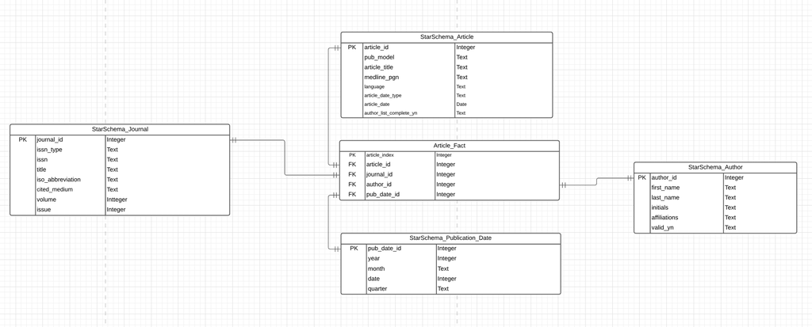

```r
# Setup new connection for star schema
#fpath = "/Users/sunjitdhillon/Desktop/"
fpath = "/Users/mmorshed/"
dbfile = "pubmedDB.db"
dbcon2 <- dbConnect(RSQLite::SQLite(), paste0(fpath,dbfile))
```

```sql
PRAGMA foreign_keys = ON
```

# Creating tables from star schema

```sql
DROP TABLE IF EXISTS StarSchema_Journal;
```

```sql
CREATE TABLE StarSchema_Journal(
journal_id INTEGER NOT NULL,
issn_type TEXT,
issn TEXT,
title TEXT,
iso_abbreviation TEXT,
cited_medium TEXT,
volume INTEGER,
issue INTEGER,
PRIMARY KEY (journal_id)
)
```

```sql
DROP TABLE IF EXISTS StarSchema_Author
```

```sql
CREATE TABLE StarSchema_Author (
author_id INTEGER NOT NULL,
last_name TEXT,
fore_name TEXT,
initials TEXT,
affiliations TEXT,
valid_yn TEXT,
PRIMARY KEY (author_id)
)
```

```sql
DROP TABLE IF EXISTS StarSchema_Article
```

```sql
CREATE TABLE StarSchema_Article(
article_id INTEGER NOT NULL,
pub_model TEXT,
article_title TEXT,
medline_pgn TEXT,
language TEXT,
article_date_type TEXT,
article_date DATE,
author_list_complete_yn TEXT,
PRIMARY KEY (article_id)
)
```

```sql
DROP TABLE IF EXISTS StarSchema_Publication_Date
```

```sql
CREATE TABLE StarSchema_Publication_Date(
pub_date_id INTEGER NOT NULL,
year INTEGER,
month TEXT,
day INTEGER,
quarter TEXT,
PRIMARY KEY (pub_date_id )
)
```

```sql
DROP TABLE IF EXISTS StarSchema_Article_Fact
```

```sql
CREATE TABLE StarSchema_Article_Fact(
article_index INTEGER NOT NULL,
article_id INTEGER NOT NULL,
journal_id INTEGER NOT NULL,
author_id INTEGER NOT NULL,
pub_date_id INTEGER NOT NULL,
PRIMARY KEY (article_index),
FOREIGN KEY (author_id) REFERENCES StarSchema_Author(author_id) ON DELETE CASCADE,
FOREIGN KEY (journal_id) REFERENCES StarSchema_Journal(journal_id) ON DELETE CASCADE,
FOREIGN KEY (article_id) REFERENCES StarSchema_Article(article_id) ON DELETE CASCADE,
FOREIGN KEY (pub_date_id) REFERENCES StarSchema_Publication_Date(pub_date_id) ON DELETE CASCADE
)
```

# Populating the data frames needed to execute start schema

```r
# Populating StarSchema_Journal.df
StarSchema_Journal.df <- merge(Journal.df,subset(Journalissue.df, select = -c(year,month,day) ),by="journal_iss_id")
StarSchema_Journal.df <- select(StarSchema_Journal.df,-c(journal_iss_id))
StarSchema_Journal.df
```

| journal_id | issn_type | issn | title | iso_abbreviation | cited_medium | volume | issue |
| --- | --- | --- | --- | --- | --- | --- | --- |
| 1 | Print | 1556-3316 | HSS journal : the musculoskeletal journal of Hospital for Special Surgery | HSS J | Print | 8 | 2 |
| 2 | Electronic | 1545-7206 | Psychosomatics | Psychosomatics | Internet | 54 | 2 |
| 3 | Electronic | 1524-4628 | Stroke; a journal of cerebral circulation | Stroke | Internet | 43 | 11 |
| 4 | Electronic | 1532-8651 | Regional anesthesia and pain medicine | Reg Anesth Pain Med | Internet | 37 | 6 |
| 5 | Electronic | 1532-2688 | Seizure : the journal of the British Epilepsy Association | Seizure | Internet | 22 | 1 |
| 6 | Electronic | 1528-1132 | Clinical orthopaedics and related research | Clin. Orthop. Relat. Res. | Internet | 471 | 1 |
| 7 | Electronic | 1532-8406 | The Journal of arthroplasty | J Arthroplasty | Internet | 27 | 10 |
| 8 | Electronic | 1528-1175 | Anesthesiology | Anesthesiology | Internet | 117 | 1 |
| 9 | Electronic | 1432-1998 | Pediatric radiology | Pediatr Radiol | Internet | 42 | 8 |
| 10 | Electronic | 1530-0358 | Diseases of the colon and rectum | Dis. Colon Rectum | Internet | 55 | 4 |

[output cut: 9 more lines]

```r
# Populating Publication_Date.df
StarSchema_Publication_Date.df <- data.frame(Journalissue.df$year, Journalissue.df$month, Journalissue.df$day)
StarSchema_Publication_Date.df <- rename(StarSchema_Publication_Date.df, year = Journalissue.df.year, month = Journalissue.df.month,
                                         day = Journalissue.df.day)
pub_date_id <- seq_len(nrow(StarSchema_Publication_Date.df))
StarSchema_Publication_Date.df <- cbind(pub_date_id, StarSchema_Publication_Date.df)
```

```r
# Enhancing StarSchema_Publication_Date.df to have a row with per quarter articles
quarter1 <- c("Jan", "Feb", "Mar");
quarter2 <- c("Apr", "May", "Jun");
quarter3 <- c("Jul", "Aug", "Sep");
quarter4 <- c("Oct", "Nov", "Dec");
for(i in 1:nrow(StarSchema_Publication_Date.df)) {
  if(StarSchema_Publication_Date.df$month[i] %in% quarter1){
      StarSchema_Publication_Date.df$quarter[i] = "1"
  } else if (StarSchema_Publication_Date.df$month[i]  %in% quarter2) {
    StarSchema_Publication_Date.df$quarter[i] = "2"
  } else if (StarSchema_Publication_Date.df$month[i]  %in% quarter3) {
    StarSchema_Publication_Date.df$quarter[i] = "3"
  } else if (StarSchema_Publication_Date.df$month[i]  %in% quarter4) {
    StarSchema_Publication_Date.df$quarter[i] = "4"
  } else {
    StarSchema_Publication_Date.df$quarter[i] = "-1"
  }
}

StarSchema_Publication_Date.df
```

| pub_date_id | year | month | day | quarter |
| --- | --- | --- | --- | --- |
| 1 | 2012 | Jul | NA | 3 |
| 2 | 2013 | Mar | NA | 1 |
| 3 | 2012 | Nov | NA | 4 |
| 4 | 2012 | Nov | NA | 4 |
| 5 | 2013 | Jan | NA | 1 |
| 6 | 2013 | Jan | NA | 1 |
| 7 | 2012 | Dec | NA | 4 |
| 8 | 2012 | Jul | NA | 3 |
| 9 | 2012 | Aug | NA | 3 |
| 10 | 2012 | Apr | NA | 2 |

[output cut: 9 more lines]

```r
# Creating StarSchema_Article.df
StarSchema_Article.df <- data.frame (article_id = integer(),
                          pub_model = character(),
                          article_title = character(),
                          medline_pgn = character(),
                          language = character(),
                          article_date_type = character(),
                          article_date = character(),
                          author_list_complete_yn = character(),
                          stringsAsFactors = F)
```

```r
# creating StartSchema_Article.df using Article.df
StarSchema_Article.df <- select(Article.df,-c(journal_id))
StarSchema_Article.df
```

|  | article_id | pub_model | article_title | medline_pgn | language | article_date_type | article_date | author_list_complete_yn |
| --- | --- | --- | --- | --- | --- | --- | --- | --- |
| 1 | 1 | Print-Electronic | Regional anesthesia for children undergoing orthopedic ambulatory surgeries in the United States, 1996-2006. | 133-6 | eng | Electronic | 2012-06-20 | Y |
| 2 | 2 | Print-Electronic | Demographics and perioperative outcome in patients with depression and anxiety undergoing total joint arthroplasty: a population-based study. | 149-57 | eng | Electronic | 2012-11-27 | Y |
| 3 | 3 | Print | Cerebrovascular reserve and stroke risk in patients with carotid stenosis or occlusion: a systematic review and meta-analysis. | 2884-91 | eng | NA | NA | Y |
| 4 | 4 | Print | Comparative perioperative outcomes associated with neuraxial versus general anesthesia for simultaneous bilateral total knee arthroplasty. | 638-44 | eng | NA | NA | Y |
| 5 | 5 | Print-Electronic | Vagus nerve stimulation vs. corpus callosotomy in the treatment of Lennox-Gastaut syndrome: a meta-analysis. | 3-8 | eng | Electronic | 2012-10-12 | Y |
| 6 | 6 | Print-Electronic | Have bilateral total knee arthroplasties become safer? A population-based trend analysis. | 17-25 | eng | Electronic | 2012-09-25 | Y |
| 7 | 7 | Print-Electronic | The metabolic syndrome in patients undergoing knee and hip arthroplasty: trends and in-hospital outcomes in the United States. | 1743-1749.e1 | eng | Electronic | 2012-06-05 | Y |
| 8 | 8 | Print | Utilization of critical care services among patients undergoing total hip and knee arthroplasty: epidemiology and risk factors. | 107-16 | eng | NA | NA | Y |
| 9 | 9 | Print-Electronic | Visualization of the normal appendix with MR enterography in children. | 959-64 | eng | Electronic | 2012-03-21 | Y |
| 10 | 10 | Print | FDG-PET assessment of rectal cancer response to neoadjuvant chemoradiotherapy is not associated with long-term prognosis: a prospective evaluation. | 378-86 | eng | NA | NA | Y |

[output cut: 9 more lines]

```r
# Create Article_Fact.df
Article_Fact.df <- data.frame (article_index = integer(),
                          article_id = integer(),
                          journal_id = integer(),
                          author_id = integer(),
                          pub_date_id = integer(),
                          stringsAsFactors = F)
```

```r
# Populate Article_Fact.df
id <- 0
for (i in 1:nrow(Article.df)) {
  journal_id <- Article.df$journal_id[i]
  journal_iss_id <- Journal.df$journal_iss_id[journal_id]
  for (j in 1:nrow(Author_list.df)) {
    if (Author_list.df$article_id[j] == i) {
      id <- id + 1
      Article_Fact.df[id,1] <- id
      Article_Fact.df[id,2] <- i
      Article_Fact.df[id,3] <- journal_id
      Article_Fact.df[id,4] <- Author_list.df$author_id[j]
      Article_Fact.df[id,5] <- journal_iss_id
    }

  }

}
Article_Fact.df
```

|  | article_index | article_id | journal_id | author_id | pub_date_id |
| --- | --- | --- | --- | --- | --- |
| 1 | 1 | 1 | 1 | 1 | 1 |
| 2 | 2 | 1 | 1 | 2 | 1 |
| 3 | 3 | 1 | 1 | 3 | 1 |
| 4 | 4 | 1 | 1 | 4 | 1 |
| 5 | 5 | 2 | 2 | 5 | 2 |
| 6 | 6 | 2 | 2 | 6 | 2 |
| 7 | 7 | 2 | 2 | 7 | 2 |
| 8 | 8 | 2 | 2 | 3 | 2 |
| 9 | 9 | 2 | 2 | 8 | 2 |
| 10 | 10 | 2 | 2 | 9 | 2 |

[output cut: 126 more lines]

# Populating the SQLite Tables with data from dataframes just created for start schema.

```r
dbWriteTable(dbcon2, "StarSchema_Author", Author.df, append = TRUE,
             row.names = FALSE)
```

```r
dbWriteTable(dbcon2, "StarSchema_Publication_Date", StarSchema_Publication_Date.df, append = TRUE,
             row.names = FALSE)
```

```r
dbWriteTable(dbcon2, "StarSchema_Journal", StarSchema_Journal.df, append = TRUE,
             row.names = FALSE)
```

```r
dbWriteTable(dbcon2, "StarSchema_Article", StarSchema_Article.df, append = TRUE,
             row.names = FALSE)
```

```r
dbWriteTable(dbcon2, "StarSchema_Article_Fact", Article_Fact.df, append = TRUE,
             row.names = FALSE)
```

# Showing that database query works using SELECT statement

```sql
SELECT * FROM StarSchema_Author
```

Displaying records 1 - 10

| author_id | last_name | fore_name | initials | affiliations | valid_yn |
| --- | --- | --- | --- | --- | --- |
| 1 | Kuo | Cassie | C | Department of Anesthesiology, Hospital for Special Surgery, 535 East 70th Street, New York, NY 10021 USA. | Y |
| 2 | Edwards | Alison | A | NA | Y |
| 3 | Mazumdar | Madhu | M | NA | Y |
| 4 | Memtsoudis | Stavros G | SG | NA | Y |
| 5 | Stundner | Ottokar | O | Department of Anesthesiology, Hospital for Special Surgery, Weill Medical College of Cornell University, New York, NY, USA. | Y |
| 6 | Kirksey | Meghan | M | NA | Y |
| 7 | Chiu | Ya Lin | YL | NA | Y |
| 8 | Poultsides | Lazaros | L | NA | Y |
| 9 | Gerner | Peter | P | NA | Y |
| 10 | Gupta | Ajay | A | Department of Radiology, Weill Cornell Medical School, New York-Presbyterian Hospital, 525 East 68th Street, Starr 8A, Box 141, New York, NY 10065, USA. ajg9004@med.cornell.edu | Y |

```sql
SELECT * FROM StarSchema_Publication_Date
```

Displaying records 1 - 10

| pub_date_id | year | month | day | quarter |
| --- | --- | --- | --- | --- |
| 1 | 2012 | Jul | NA | 3 |
| 2 | 2013 | Mar | NA | 1 |
| 3 | 2012 | Nov | NA | 4 |
| 4 | 2012 | Nov | NA | 4 |
| 5 | 2013 | Jan | NA | 1 |
| 6 | 2013 | Jan | NA | 1 |
| 7 | 2012 | Dec | NA | 4 |
| 8 | 2012 | Jul | NA | 3 |
| 9 | 2012 | Aug | NA | 3 |
| 10 | 2012 | Apr | NA | 2 |

```sql
SELECT * FROM StarSchema_Journal
```

Displaying records 1 - 10

| journal_id | issn_type | issn | title | iso_abbreviation | cited_medium | volume | issue |
| --- | --- | --- | --- | --- | --- | --- | --- |
| 1 | Print | 1556-3316 | HSS journal : the musculoskeletal journal of Hospital for Special Surgery | HSS J | Print | 8 | 2 |
| 2 | Electronic | 1545-7206 | Psychosomatics | Psychosomatics | Internet | 54 | 2 |
| 3 | Electronic | 1524-4628 | Stroke; a journal of cerebral circulation | Stroke | Internet | 43 | 11 |
| 4 | Electronic | 1532-8651 | Regional anesthesia and pain medicine | Reg Anesth Pain Med | Internet | 37 | 6 |
| 5 | Electronic | 1532-2688 | Seizure : the journal of the British Epilepsy Association | Seizure | Internet | 22 | 1 |
| 6 | Electronic | 1528-1132 | Clinical orthopaedics and related research | Clin. Orthop. Relat. Res. | Internet | 471 | 1 |
| 7 | Electronic | 1532-8406 | The Journal of arthroplasty | J Arthroplasty | Internet | 27 | 10 |
| 8 | Electronic | 1528-1175 | Anesthesiology | Anesthesiology | Internet | 117 | 1 |
| 9 | Electronic | 1432-1998 | Pediatric radiology | Pediatr Radiol | Internet | 42 | 8 |
| 10 | Electronic | 1530-0358 | Diseases of the colon and rectum | Dis. Colon Rectum | Internet | 55 | 4 |

```sql
SELECT * FROM StarSchema_Article
```

Displaying records 1 - 10

| article_id | pub_model | article_title | medline_pgn | language | article_date_type | article_date | author_list_complete_yn |
| --- | --- | --- | --- | --- | --- | --- | --- |
| 1 | Print-Electronic | Regional anesthesia for children undergoing orthopedic ambulatory surgeries in the United States, 1996-2006. | 133-6 | eng | Electronic | 2012-06-20 | Y |
| 2 | Print-Electronic | Demographics and perioperative outcome in patients with depression and anxiety undergoing total joint arthroplasty: a population-based study. | 149-57 | eng | Electronic | 2012-11-27 | Y |
| 3 | Print | Cerebrovascular reserve and stroke risk in patients with carotid stenosis or occlusion: a systematic review and meta-analysis. | 2884-91 | eng | NA | NA | Y |
| 4 | Print | Comparative perioperative outcomes associated with neuraxial versus general anesthesia for simultaneous bilateral total knee arthroplasty. | 638-44 | eng | NA | NA | Y |
| 5 | Print-Electronic | Vagus nerve stimulation vs. corpus callosotomy in the treatment of Lennox-Gastaut syndrome: a meta-analysis. | 3-8 | eng | Electronic | 2012-10-12 | Y |
| 6 | Print-Electronic | Have bilateral total knee arthroplasties become safer? A population-based trend analysis. | 17-25 | eng | Electronic | 2012-09-25 | Y |
| 7 | Print-Electronic | The metabolic syndrome in patients undergoing knee and hip arthroplasty: trends and in-hospital outcomes in the United States. | 1743-1749.e1 | eng | Electronic | 2012-06-05 | Y |
| 8 | Print | Utilization of critical care services among patients undergoing total hip and knee arthroplasty: epidemiology and risk factors. | 107-16 | eng | NA | NA | Y |
| 9 | Print-Electronic | Visualization of the normal appendix with MR enterography in children. | 959-64 | eng | Electronic | 2012-03-21 | Y |
| 10 | Print | FDG-PET assessment of rectal cancer response to neoadjuvant chemoradiotherapy is not associated with long-term prognosis: a prospective evaluation. | 378-86 | eng | NA | NA | Y |

```sql
SELECT * FROM StarSchema_Article_Fact
```

Displaying records 1 - 10

| article_index | article_id | journal_id | author_id | pub_date_id |
| --- | --- | --- | --- | --- |
| 1 | 1 | 1 | 1 | 1 |
| 2 | 1 | 1 | 2 | 1 |
| 3 | 1 | 1 | 3 | 1 |
| 4 | 1 | 1 | 4 | 1 |
| 5 | 2 | 2 | 5 | 2 |
| 6 | 2 | 2 | 6 | 2 |
| 7 | 2 | 2 | 7 | 2 |
| 8 | 2 | 2 | 3 | 2 |
| 9 | 2 | 2 | 8 | 2 |
| 10 | 2 | 2 | 9 | 2 |

# Adding a snapshot for database to show tables and a query

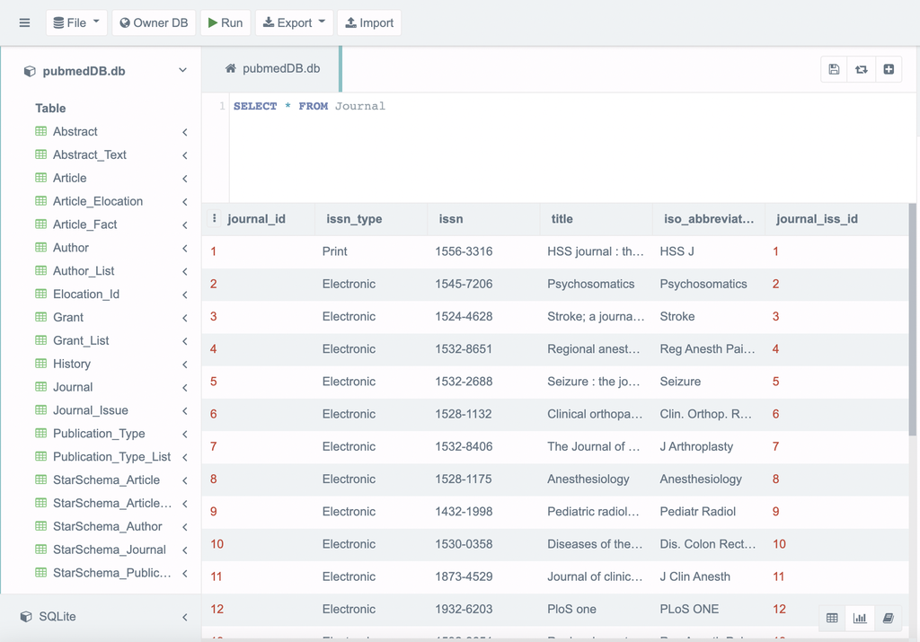

Screenshot of database inspected in SQLite

# PART 2 Q2

ERD link from Part1 contains ERD for Part 2 Q2 also.

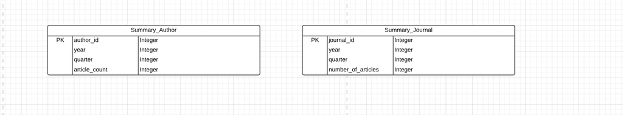

Part2 Ques2: Summary Tables

# Using the database created and loaded with data in part 2 Q1, summary tables are created for Part 2 Q2

```r
sqlCmd = "SELECT author_id, year, quarter, count(distinct(article_id)) as number_of_articles
FROM StarSchema_Article_Fact
NATURAL JOIN StarSchema_Publication_Date
GROUP BY author_id, year, quarter
ORDER BY author_id, year, quarter"
summary_author_year_quarter = dbGetQuery(dbcon2, sqlCmd)
summary_author_year_quarter
```

| author_id | year | quarter | number_of_articles |
| --- | --- | --- | --- |
| 1 | 2012 | 3 | 1 |
| 2 | 2012 | 3 | 1 |
| 3 | 2012 | -1 | 1 |
| 3 | 2012 | 1 | 4 |
| 3 | 2012 | 2 | 4 |
| 3 | 2012 | 3 | 4 |
| 3 | 2012 | 4 | 3 |
| 3 | 2013 | 1 | 3 |
| 4 | 2012 | 1 | 3 |
| 4 | 2012 | 2 | 2 |

[output cut: 102 more lines]

```r
sqlCmd2 = "SELECT author_id, year,quarter = 0 as quarter, count(distinct(article_id)) as number_of_articles
FROM StarSchema_Article_Fact
NATURAL JOIN StarSchema_Publication_Date
GROUP BY author_id, year
ORDER BY author_id, year"
summary_author_year = dbGetQuery(dbcon2, sqlCmd2)
summary_author_year
```

| author_id | year | quarter | number_of_articles |
| --- | --- | --- | --- |
| 1 | 2012 | 0 | 1 |
| 2 | 2012 | 0 | 1 |
| 3 | 2012 | 0 | 16 |
| 3 | 2013 | 0 | 3 |
| 4 | 2012 | 0 | 10 |
| 4 | 2013 | 0 | 2 |
| 5 | 2012 | 0 | 2 |
| 5 | 2013 | 0 | 2 |
| 6 | 2012 | 0 | 1 |
| 6 | 2013 | 0 | 1 |

[output cut: 82 more lines]

```r
sqlCmd3 = "SELECT author_id, year = 0 as year,quarter, count(distinct(article_id)) as number_of_articles
FROM StarSchema_Article_Fact
NATURAL JOIN StarSchema_Publication_Date
GROUP BY author_id, quarter
ORDER BY author_id, year, quarter"
summary_author_quarter = dbGetQuery(dbcon2, sqlCmd3)
summary_author_quarter
```

| author_id | year | quarter | number_of_articles |
| --- | --- | --- | --- |
| 1 | 0 | 3 | 1 |
| 2 | 0 | 3 | 1 |
| 3 | 0 | -1 | 1 |
| 3 | 0 | 1 | 7 |
| 3 | 0 | 2 | 4 |
| 3 | 0 | 3 | 4 |
| 3 | 0 | 4 | 3 |
| 4 | 0 | 1 | 5 |
| 4 | 0 | 2 | 2 |
| 4 | 0 | 3 | 3 |

[output cut: 99 more lines]

# Using our summary table “summary_author”, we can find :

# 1. Number of articles published by an author in a given year (where quarter = 0)

# 2. Number of articles published by an author in a given quarter (where year = 0)

# 3. Number of articles published by an author in a given quarter of a given year

```r
total <- nrow(summary_author_year) + nrow(summary_author_year_quarter) + nrow(summary_author_quarter)
summary_author <- data.frame (id = integer(),
                          stringsAsFactors = F)
for (i in 1:total) {
  summary_author[i,1] <- i
}
summary_author2 <- rbind(summary_author_year_quarter, summary_author_year, summary_author_quarter)

summary_author <- cbind(summary_author, summary_author2)
summary_author
```

|  | id | author_id | year | quarter | number_of_articles |
| --- | --- | --- | --- | --- | --- |
| 1 | 1 | 1 | 2012 | 3 | 1 |
| 2 | 2 | 2 | 2012 | 3 | 1 |
| 3 | 3 | 3 | 2012 | -1 | 1 |
| 4 | 4 | 3 | 2012 | 1 | 4 |
| 5 | 5 | 3 | 2012 | 2 | 4 |
| 6 | 6 | 3 | 2012 | 3 | 4 |
| 7 | 7 | 3 | 2012 | 4 | 3 |
| 8 | 8 | 3 | 2013 | 1 | 3 |
| 9 | 9 | 4 | 2012 | 1 | 3 |
| 10 | 10 | 4 | 2012 | 2 | 2 |

[output cut: 303 more lines]

# Example: This functions searches for the number of articles published by a particular author in a given year.

```r
search_by_authorId_by_year <- function(author_id, year) {
  result = 0
  for (i in 1:nrow(summary_author)) {
    if(author_id == summary_author$author_id[i] && year == summary_author$year[i] && summary_author$quarter[i] == 0){
      result = summary_author$number_of_articles[i];
    }
  }
  print(result);
}
```

```r
search_by_authorId_by_year(1,2012)  # 1
```

```
## [1] 1
```

```r
search_by_authorId_by_year(3,2012)  # 16
```

```
## [1] 16
```

# Using the database created and loaded with data in part 2 Q1, summary table is created for Part 2 Q2

```r
sqlCmd4 = "SELECT issn, year, quarter, count(distinct(article_id)) as number_of_articles
FROM StarSchema_Article_Fact
NATURAL JOIN StarSchema_Publication_Date
NATURAL JOIN StarSchema_Journal
GROUP BY issn, year, quarter
ORDER BY issn, year, quarter"
summary_journal_year_quarter = dbGetQuery(dbcon2, sqlCmd4)
summary_journal_year_quarter
```

| issn | year | quarter | number_of_articles |
| --- | --- | --- | --- |
| 1097-0142 | 2012 | 2 | 1 |
| 1432-1998 | 2012 | 3 | 1 |
| 1464-410X | 2012 | 1 | 1 |
| 1524-4628 | 2012 | 4 | 1 |
| 1525-1489 | 2012 | 3 | 1 |
| 1528-1132 | 2013 | 1 | 1 |
| 1528-1159 | 2012 | 1 | 1 |
| 1528-1159 | 2012 | 2 | 1 |
| 1528-1175 | 2012 | 3 | 1 |
| 1530-0358 | 2012 | 2 | 1 |

[output cut: 9 more lines]

```r
sqlCmd5 = "SELECT issn, year,quarter = 0 as quarter, count(distinct(article_id)) as number_of_articles
FROM StarSchema_Article_Fact
NATURAL JOIN StarSchema_Publication_Date
NATURAL JOIN StarSchema_Journal
GROUP BY issn, year
ORDER BY issn, year"
summary_journal_year = dbGetQuery(dbcon2, sqlCmd5)
summary_journal_year
```

| issn | year | quarter | number_of_articles |
| --- | --- | --- | --- |
| 1097-0142 | 2012 | 0 | 1 |
| 1432-1998 | 2012 | 0 | 1 |
| 1464-410X | 2012 | 0 | 1 |
| 1524-4628 | 2012 | 0 | 1 |
| 1525-1489 | 2012 | 0 | 1 |
| 1528-1132 | 2013 | 0 | 1 |
| 1528-1159 | 2012 | 0 | 2 |
| 1528-1175 | 2012 | 0 | 1 |
| 1530-0358 | 2012 | 0 | 1 |
| 1532-2688 | 2013 | 0 | 1 |

[output cut: 6 more lines]

```r
sqlCmd6 = "SELECT issn, year = 0 as year, quarter, count(distinct(article_id)) as number_of_articles
FROM StarSchema_Article_Fact
NATURAL JOIN StarSchema_Publication_Date
NATURAL JOIN StarSchema_Journal
GROUP BY issn, quarter
ORDER BY issn, quarter"
summary_journal_quarter = dbGetQuery(dbcon2, sqlCmd6)
summary_journal_quarter
```

| issn | year | quarter | number_of_articles |
| --- | --- | --- | --- |
| 1097-0142 | 0 | 2 | 1 |
| 1432-1998 | 0 | 3 | 1 |
| 1464-410X | 0 | 1 | 1 |
| 1524-4628 | 0 | 4 | 1 |
| 1525-1489 | 0 | 3 | 1 |
| 1528-1132 | 0 | 1 | 1 |
| 1528-1159 | 0 | 1 | 1 |
| 1528-1159 | 0 | 2 | 1 |
| 1528-1175 | 0 | 3 | 1 |
| 1530-0358 | 0 | 2 | 1 |

[output cut: 9 more lines]

# Using our summary table “summary_journal”, we can find :

# 1. Number of articles published in a journal in a given year (where quarter = 0)

# 2. Number of articles published in a journal in a given quarter (where year = 0)

# 3. Number of articles published in a journal in a given quarter of a given year

```r
total <- nrow(summary_journal_year) + nrow(summary_journal_year_quarter) + nrow(summary_journal_quarter)
summary_journal <- data.frame (id = integer(),
                          stringsAsFactors = F)
for (i in 1:total) {
  summary_journal[i,1] <- i
}
summary_journal2 <- rbind(summary_journal_year_quarter, summary_journal_year, summary_journal_quarter)

summary_journal <- cbind(summary_journal, summary_journal2)
summary_journal
```

|  | id | issn | year | quarter | number_of_articles |
| --- | --- | --- | --- | --- | --- |
| 1 | 1 | 1097-0142 | 2012 | 2 | 1 |
| 2 | 2 | 1432-1998 | 2012 | 3 | 1 |
| 3 | 3 | 1464-410X | 2012 | 1 | 1 |
| 4 | 4 | 1524-4628 | 2012 | 4 | 1 |
| 5 | 5 | 1525-1489 | 2012 | 3 | 1 |
| 6 | 6 | 1528-1132 | 2013 | 1 | 1 |
| 7 | 7 | 1528-1159 | 2012 | 1 | 1 |
| 8 | 8 | 1528-1159 | 2012 | 2 | 1 |
| 9 | 9 | 1528-1175 | 2012 | 3 | 1 |
| 10 | 10 | 1530-0358 | 2012 | 2 | 1 |

[output cut: 44 more lines]

# Example: This functions searches for the number of articles published in a particular journal in a given year.

```r
search_by_journal_by_year <- function(issn, year) {
  result = 0
  for (i in 1:nrow(summary_journal)) {
    if(issn == summary_journal$issn[i] && year == summary_journal$year[i] && summary_journal$quarter[i] == 0){
      result = summary_journal$number_of_articles[i];
    }
  }
  print(result);
}
```

```r
search_by_journal_by_year("1097-0142",2012)  # 1
```

```
## [1] 1
```

```r
search_by_journal_by_year("1432-1998",2012)  # 1
```

```
## [1] 1
```

# PART 3

# Author Summary

```r
#summary_author <- cbind(summary_author, summary_author2)
df <- subset(summary_author, select = c(author_id, quarter, number_of_articles) )
df <- df[df$quarter != 0,]
df
```

|  | author_id | quarter | number_of_articles |
| --- | --- | --- | --- |
| 1 | 1 | 3 | 1 |
| 2 | 2 | 3 | 1 |
| 3 | 3 | -1 | 1 |
| 4 | 3 | 1 | 4 |
| 5 | 3 | 2 | 4 |
| 6 | 3 | 3 | 4 |
| 7 | 3 | 4 | 3 |
| 8 | 3 | 1 | 3 |
| 9 | 4 | 1 | 3 |
| 10 | 4 | 2 | 2 |

[output cut: 211 more lines]

```r
df2 <-df %>%
  group_by(quarter) %>%
  summarise(count=sum(number_of_articles))
df2
```

| quarter | count |
| --- | --- |
| -1 | 24 |
| 1 | 90 |
| 2 | 64 |
| 3 | 44 |
| 4 | 50 |

# This barplot shows the number of articles published by authors/quarter (Quarter = -1 represents the articles for which the data was not complete). The bar plot clearly shows that the maximum number of articles were published in quarter 1.

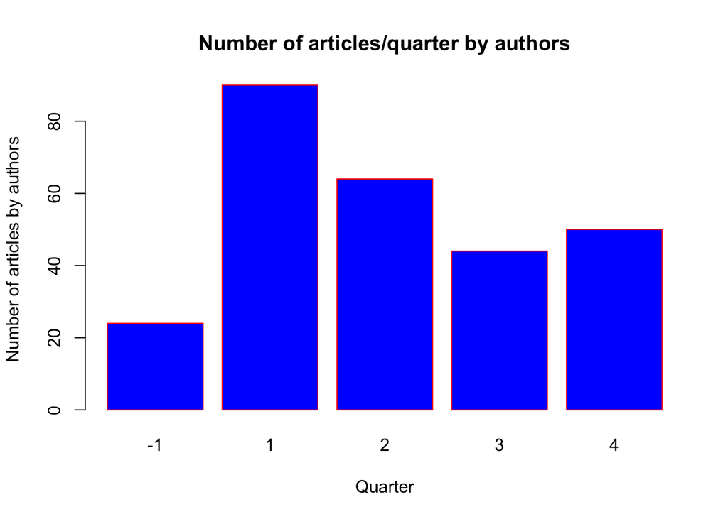

```r
barplot(df2$count,names.arg=df2$quarter,xlab="Quarter",ylab="Number of articles by authors",col="blue",
main="Number of articles/quarter by authors",border="red")
```

```r
summary_author <- summary_author[summary_author$quarter == 0,]
df3 <- subset(summary_author, select = c(author_id, year, number_of_articles) )
df3
```

|  | author_id | year | number_of_articles |
| --- | --- | --- | --- |
| 113 | 1 | 2012 | 1 |
| 114 | 2 | 2012 | 1 |
| 115 | 3 | 2012 | 16 |
| 116 | 3 | 2013 | 3 |
| 117 | 4 | 2012 | 10 |
| 118 | 4 | 2013 | 2 |
| 119 | 5 | 2012 | 2 |
| 120 | 5 | 2013 | 2 |
| 121 | 6 | 2012 | 1 |
| 122 | 6 | 2013 | 1 |

[output cut: 82 more lines]

```r
df4 <-df3 %>%
  group_by(year) %>%
  summarise(count=sum(number_of_articles))
df4
```

| year | count |
| --- | --- |
| 2012 | 117 |
| 2013 | 19 |

# This barplot represents the number of articles published by authors/year. The plot clearly shows that the authors published more articles in year 2012. This may be due to the fact that the given data is incomplete and doesn’t cover complete record for year 2013.

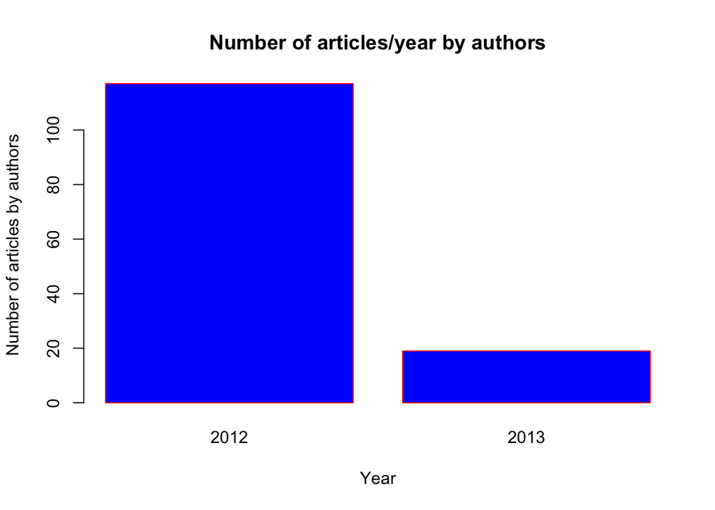

```r
barplot(df4$count,names.arg=df4$year,xlab="Year",ylab="Number of articles by authors",col="blue",
main="Number of articles/year by authors",border="red")
```

# This stacked graph shows that author_id = 3 published the maximum number of articles.

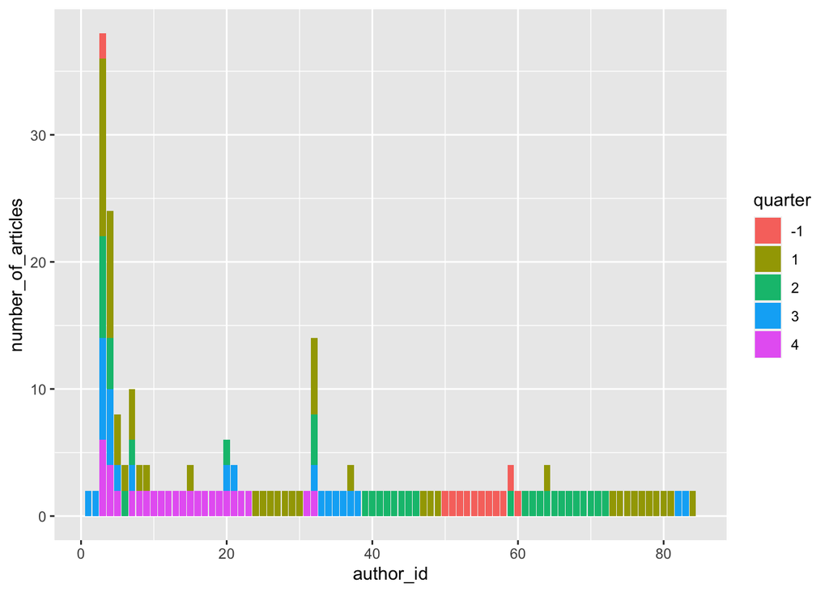

```r
# This plot shows for each author, number of articles per quarter. Quarter = -1 represents the articles
# for which the data was not complete
ggplot(df, aes(fill=quarter, y=number_of_articles, x=author_id)) +
    geom_bar(position="stack", stat="identity")
```

# Example: This functions searches for the number of articles published by a particular author in a given year.

```r
search_by_authorId_by_year <- function(author_id, year) {
  result = 0
  for (i in 1:nrow(summary_author)) {
    if(author_id == summary_author$author_id[i] && year == summary_author$year[i] && summary_author$quarter[i] == 0){
      result = summary_author$number_of_articles[i];
    }
  }
  print(result);
}
```

```r
search_by_authorId_by_year(1,2012)  # 1
```

```
## [1] 1
```

```r
search_by_authorId_by_year(3,2012)  # 16
```

```
## [1] 16
```

# Journal Summary

```r
df_j <- summary_journal[summary_journal$year == 0,]
df_j <- subset(df_j, select = c(issn, quarter, number_of_articles) )
df_j
```

|  | issn | quarter | number_of_articles |
| --- | --- | --- | --- |
| 36 | 1097-0142 | 2 | 1 |
| 37 | 1432-1998 | 3 | 1 |
| 38 | 1464-410X | 1 | 1 |
| 39 | 1524-4628 | 4 | 1 |
| 40 | 1525-1489 | 3 | 1 |
| 41 | 1528-1132 | 1 | 1 |
| 42 | 1528-1159 | 1 | 1 |
| 43 | 1528-1159 | 2 | 1 |
| 44 | 1528-1175 | 3 | 1 |
| 45 | 1530-0358 | 2 | 1 |

[output cut: 9 more lines]

```r
df_j <-df_j %>%
  group_by(quarter) %>%
  summarise(count=sum(number_of_articles))
df_j
```

| quarter | count |
| --- | --- |
| -1 | 1 |
| 1 | 7 |
| 2 | 4 |
| 3 | 4 |
| 4 | 3 |